# NCDB Polymorphous Low Grade Adenocarcinoma

All

Ramie Fathy

September 11, 2018

**Note: To hide the code from this document, click the button in the upper right corner.**

```r
col.width <- c(37, 10, 1, 1, 3, 1, 2, 1, 2, 1, 1, 1, 1, 1, 1, 8, 2, 2, 2, 4, 4, 1, 4, 1, 1, 1, 3, 2, 2, 8,
               2, 5, 5, 5, 4, 5, 5, 5, 4, 2, 1, 2, 1, 3, 1, 1, 1, 1, 1, 1, 3, 3, 3, 3, 3, 3, 3, 3, 3, 3, 3,
               3, 3, 3, 3, 3, 3, 3, 3, 3, 3, 3, 3, 3, 3, 6, 8, 8, 8, 2, 1, 1, 1, 1, 8, 1, 1, 8, 1, 1, 2,
               2, 5, 2, 5, 3, 1, 3, 1, 8, 8, 2, 8, 2, 8, 2, 2, 1, 8, 1, 1, 1, 1, 1, 8, 1, 2, 2, 2, 2, 2,
               1, 1, 1, 2, 1)
col.names.abr <- c("PUF_CASE_ID", "PUF_FACILITY_ID", "FACILITY_TYPE_CD",  "FACILITY_LOCATION_CD", "AGE", "SEX", "RACE",
                   "SPANISH_HISPANIC_ORIGIN", "INSURANCE_STATUS", "MED_INC_QUAR_00", "NO_HSD_QUAR_00", "UR_CD_03",
                   "MED_INC_QUAR_12", "NO_HSD_QUAR_12", "UR_CD_13", "CROWFLY", "CDCC_TOTAL", "SEQUENCE_NUMBER",
                   "CLASS_OF_CASE", "YEAR_OF_DIAGNOSIS", "PRIMARY_SITE",  "LATERALITY", "HISTOLOGY", "BEHAVIOR",
                   "GRADE", "DIAGNOSTIC_CONFIRMATION", "TUMOR_SIZE", "REGIONAL_NODES_POSITIVE",
                   "REGIONAL_NODES_EXAMINED", "DX_STAGING_PROC_DAYS", "RX_SUMM_DXSTG_PROC", "TNM_CLIN_T",
                   "TNM_CLIN_N", "TNM_CLIN_M", "TNM_CLIN_STAGE_GROUP", "TNM_PATH_T", "TNM_PATH_N", "TNM_PATH_M",
                   "TNM_PATH_STAGE_GROUP", "TNM_EDITION_NUMBER", "ANALYTIC_STAGE_GROUP", "CS_METS_AT_DX",
                   "CS_METS_EVAL", "CS_EXTENSION", "CS_TUMOR_SIZEEXT_EVAL", "CS_METS_DX_BONE",
                   "CS_METS_DX_BRAIN", "CS_METS_DX_LIVER", "CS_METS_DX_LUNG", "LYMPH_VASCULAR_INVASION",
                   "CS_SITESPECIFIC_FACTOR_1", "CS_SITESPECIFIC_FACTOR_2", "CS_SITESPECIFIC_FACTOR_3",
                   "CS_SITESPECIFIC_FACTOR_4", "CS_SITESPECIFIC_FACTOR_5", "CS_SITESPECIFIC_FACTOR_6",
                   "CS_SITESPECIFIC_FACTOR_7", "CS_SITESPECIFIC_FACTOR_8", "CS_SITESPECIFIC_FACTOR_9",
                   "CS_SITESPECIFIC_FACTOR_10", "CS_SITESPECIFIC_FACTOR_11", "CS_SITESPECIFIC_FACTOR_12",
                   "CS_SITESPECIFIC_FACTOR_13", "CS_SITESPECIFIC_FACTOR_14", "CS_SITESPECIFIC_FACTOR_15",
                   "CS_SITESPECIFIC_FACTOR_16", "CS_SITESPECIFIC_FACTOR_17", "CS_SITESPECIFIC_FACTOR_18",
                   "CS_SITESPECIFIC_FACTOR_19", "CS_SITESPECIFIC_FACTOR_20", "CS_SITESPECIFIC_FACTOR_21",
                   "CS_SITESPECIFIC_FACTOR_22", "CS_SITESPECIFIC_FACTOR_23", "CS_SITESPECIFIC_FACTOR_24",
                   "CS_SITESPECIFIC_FACTOR_25", "CS_VERSION_LATEST", "DX_RX_STARTED_DAYS",
                   "DX_SURG_STARTED_DAYS", "DX_DEFSURG_STARTED_DAYS", "RX_SUMM_SURG_PRIM_SITE",
                   "RX_HOSP_SURG_APPR_2010", "RX_SUMM_SURGICAL_MARGINS", "RX_SUMM_SCOPE_REG_LN_SUR",
                   "RX_SUMM_SURG_OTH_REGDIS", "SURG_DISCHARGE_DAYS", "READM_HOSP_30_DAYS",
                   "REASON_FOR_NO_SURGERY", "DX_RAD_STARTED_DAYS", "RX_SUMM_RADIATION", "RAD_LOCATION_OF_RX",
                   "RAD_TREAT_VOL", "RAD_REGIONAL_RX_MODALITY", "RAD_REGIONAL_DOSE_CGY",
                   "RAD_BOOST_RX_MODALITY", "RAD_BOOST_DOSE_CGY", "RAD_NUM_TREAT_VOL",
                   "RX_SUMM_SURGRAD_SEQ", "RAD_ELAPSED_RX_DAYS", "REASON_FOR_NO_RADIATION",
                   "DX_SYSTEMIC_STARTED_DAYS", "DX_CHEMO_STARTED_DAYS", "RX_SUMM_CHEMO",
                   "DX_HORMONE_STARTED_DAYS", "RX_SUMM_HORMONE", "DX_IMMUNO_STARTED_DAYS",
                   "RX_SUMM_IMMUNOTHERAPY", "RX_SUMM_TRNSPLNT_ENDO", "RX_SUMM_SYSTEMIC_SUR_SEQ",
                   "DX_OTHER_STARTED_DAYS", "RX_SUMM_OTHER", "PALLIATIVE_CARE", "RX_SUMM_TREATMENT_STATUS",
                   "PUF_30_DAY_MORT_CD", "PUF_90_DAY_MORT_CD", "DX_LASTCONTACT_DEATH_MONTHS",
                   "PUF_VITAL_STATUS", "RX_HOSP_SURG_PRIM_SITE", "RX_HOSP_CHEMO", "RX_HOSP_IMMUNOTHERAPY",
                   "RX_HOSP_HORMONE", "RX_HOSP_OTHER", "PUF_MULT_SOURCE", "REFERENCE_DATE_FLAG",
                   "RX_SUMM_SCOPE_REG_LN_2012", "RX_HOSP_DXSTG_PROC", "PALLIATIVE_CARE_HOSP")
#Read in data for each subsite
bone.joint <- read_fwf('I:/Brant/Research/NCDB/Data/Data_2017/NCDB_PUF_DATA_Nov-07-2017/NCDBPUF_BoneJont.3.2015.0.dat',
                       fwf_widths(col.width, col_names = col.names.abr),
                       col_types = cols(.default = col_character()))
brain <- read_fwf('I:/Brant/Research/NCDB/Data/Data_2017/NCDB_PUF_DATA_Nov-07-2017/NCDBPUF_Brain.3.2015.0.dat',
                       fwf_widths(col.width, col_names = col.names.abr),
                       col_types = cols(.default = col_character()))
cns <- read_fwf('I:/Brant/Research/NCDB/Data/Data_2017/NCDB_PUF_DATA_Nov-07-2017/NCDBPUF_CNS.3.2015.0.dat',
                       fwf_widths(col.width, col_names = col.names.abr),
                       col_types = cols(.default = col_character()))
gum.ot.mth <- read_fwf('I:/Brant/Research/NCDB/Data/Data_2017/NCDB_PUF_DATA_Nov-07-2017/NCDBPUF_GumOtMth.3.2015.0.dat',
                       fwf_widths(col.width, col_names = col.names.abr),
                       col_types = cols(.default = col_character()))
hypophar <- read_fwf('I:/Brant/Research/NCDB/Data/Data_2017/NCDB_PUF_DATA_Nov-07-2017/NCDBPUF_Hypophar.3.2015.0.dat',
                       fwf_widths(col.width, col_names = col.names.abr),
                       col_types = cols(.default = col_character()))
larynx <- read_fwf('I:/Brant/Research/NCDB/Data/Data_2017/NCDB_PUF_DATA_Nov-07-2017/NCDBPUF_Larynx.3.2015.0.dat',
                       fwf_widths(col.width, col_names = col.names.abr),
                       col_types = cols(.default = col_character()))
lip <- read_fwf('I:/Brant/Research/NCDB/Data/Data_2017/NCDB_PUF_DATA_Nov-07-2017/NCDBPUF_Lip.3.2015.0.dat',
                       fwf_widths(col.width, col_names = col.names.abr),
                       col_types = cols(.default = col_character()))
melanoma <- read_fwf('I:/Brant/Research/NCDB/Data/Data_2017/NCDB_PUF_DATA_Nov-07-2017/NCDBPUF_Melanoma.3.2015.0.dat',
                       fwf_widths(col.width, col_names = col.names.abr),
                       col_types = cols(.default = col_character()))
fom <- read_fwf('I:/Brant/Research/NCDB/Data/Data_2017/NCDB_PUF_DATA_Nov-07-2017/NCDBPUF_MouthFlr.3.2015.0.dat',
                       fwf_widths(col.width, col_names = col.names.abr),
                       col_types = cols(.default = col_character()))
nasal <- read_fwf('I:/Brant/Research/NCDB/Data/Data_2017/NCDB_PUF_DATA_Nov-07-2017/NCDBPUF_Nasal.3.2015.0.dat',
                       fwf_widths(col.width, col_names = col.names.abr),
                       col_types = cols(.default = col_character()))
nasophar <- read_fwf('I:/Brant/Research/NCDB/Data/Data_2017/NCDB_PUF_DATA_Nov-07-2017/NCDBPUF_Nasophar.3.2015.0.dat',
                       fwf_widths(col.width, col_names = col.names.abr),
                       col_types = cols(.default = col_character()))
orophar <- read_fwf('I:/Brant/Research/NCDB/Data/Data_2017/NCDB_PUF_DATA_Nov-07-2017/NCDBPUF_Orophary.3.2015.0.dat',
                       fwf_widths(col.width, col_names = col.names.abr),
                       col_types = cols(.default = col_character()))
oth.endo <- read_fwf('I:/Brant/Research/NCDB/Data/Data_2017/NCDB_PUF_DATA_Nov-07-2017/NCDBPUF_OtEndocr.3.2015.0.dat',
                       fwf_widths(col.width, col_names = col.names.abr),
                       col_types = cols(.default = col_character()))
skin <- read_fwf('I:/Brant/Research/NCDB/Data/Data_2017/NCDB_PUF_DATA_Nov-07-2017/NCDBPUF_OtSkin.3.2015.0.dat',
                       fwf_widths(col.width, col_names = col.names.abr),
                       col_types = cols(.default = col_character()))
pharynx <- read_fwf('I:/Brant/Research/NCDB/Data/Data_2017/NCDB_PUF_DATA_Nov-07-2017/NCDBPUF_Pharynx.3.2015.0.dat',
                       fwf_widths(col.width, col_names = col.names.abr),
                       col_types = cols(.default = col_character()))
saliv.gland <- read_fwf('I:/Brant/Research/NCDB/Data/Data_2017/NCDB_PUF_DATA_Nov-07-2017/NCDBPUF_SalivGld.3.2015.0.dat',
                       fwf_widths(col.width, col_names = col.names.abr),
                       col_types = cols(.default = col_character()))
thyroid <- read_fwf('I:/Brant/Research/NCDB/Data/Data_2017/NCDB_PUF_DATA_Nov-07-2017/NCDBPUF_Thyroid.3.2015.0.dat',
                       fwf_widths(col.width, col_names = col.names.abr),
                       col_types = cols(.default = col_character()))
tongue <- read_fwf('I:/Brant/Research/NCDB/Data/Data_2017/NCDB_PUF_DATA_Nov-07-2017/NCDBPUF_Tongue.3.2015.0.dat',
                       fwf_widths(col.width, col_names = col.names.abr),
                       col_types = cols(.default = col_character()))
tonsil <- read_fwf('I:/Brant/Research/NCDB/Data/Data_2017/NCDB_PUF_DATA_Nov-07-2017/NCDBPUF_Tonsil.3.2015.0.dat',
                       fwf_widths(col.width, col_names = col.names.abr),
                       col_types = cols(.default = col_character()))
trach.med <- read_fwf('I:/Brant/Research/NCDB/Data/Data_2017/NCDB_PUF_DATA_Nov-07-2017/NCDBPUF_TrachMed.3.2015.0.dat',
                       fwf_widths(col.width, col_names = col.names.abr),
                       col_types = cols(.default = col_character()))
#Combine data for all subsites
dat <- bind_rows(bone.joint, brain, cns, gum.ot.mth, hypophar, larynx, lip, melanoma, fom, nasal, nasophar, orophar,
                 oth.endo, skin, pharynx, saliv.gland, thyroid, tongue, tonsil, trach.med)
rm(bone.joint, brain, cns, gum.ot.mth, hypophar, larynx, lip, melanoma, fom, nasal, nasophar, orophar,
                 oth.endo, skin, pharynx, saliv.gland, thyroid, tongue, tonsil, trach.med)
prim_site_text <- data_frame(PRIMARY_SITE = c("C030", "C031", "C062", "C039", "C050", "C051", "C052", "C058", "C059", "C068",
               "C069", "C060", "C061", "C129", "C130", "C131", "C132", "C138", "C139", "C320",
               "C321", "C322", "C323", "C328", "C329", "C000", "C003", "C001", "C004", "C006",
               "C002", "C005", "C008", "C009", "C440", "C442", "C443", "C444", "C445", "C446",
               "C447", "C448", "C449", "C441", "C040", "C041", "C048", "C049", "C300", "C301",
               "C310", "C311", "C312", "C313", "C318", "C319", "C110", "C111", "C112", "C113",
               "C118", "C119", "C090", "C091", "C098", "C099", "C100", "C102", "C103", "C104",
               "C108", "C109", "C101", "C140", "C142", "C148", "C079", "C080", "C081", "C088",
               "C089", "C739", "C019", "C024", "C020", "C021", "C022", "C023", "C028", "C029"),
               SITE_TEXT = c("C03.0: Gum, upper", "C03.1 Gum, lower", "C06.2 Retromolar area", "C03.9 Gum, NOS",
               "C05.0 Hard Palate", "C05.1 Soft Palate", "C05.2 Uvula", "C05.8 Overlapping lesion of palate",
               "C05.9 Palate NOS", "C06.8 Overlapping lesion of other an unspecified parts of mouth",
               "C06.9 Mouth, NOS", "C06.0 Buccal mucosa", "C06.1 Vestibule of mouth", "C12.9  Pyriform sinus",
               "C13.0  Postcricoid region", "C13.1  Hypopharyngeal aspect of aryepiglottic fold",
               "C13.2  Posterior wall of hypopharynx", "C13.8  Overlapping lesion of hypopharynx",
               "C13.9  Hypopharynx, NOS (laryngopharynx)", "C32.0  Glottis", "C32.1  Supraglottis",
               "C32.2  Subglottis", "C32.3  Laryngeal cartilage", "C32.8  Overlapping lesion of larynx",
               "C32.9  Larynx, NOS", "C00.0  External upper lip (vermilion)", "C00.3  Mucosa of upper lip",
               "C00.1  External lower lip (vermilion)", "C00.4  Mucosa of lower lip", "C00.6  Commissure of lip",
               "C00.2  External lip, NOS (vermilion)", "C00.5  Mucosa of lip, NOS", "C00.8  Overlapping lesion of lip",
               "C00.9  Lip, NOS (excludes skin of lip C44.0)", "C44.0  Skin of lip, NOS", "C44.2  External ear",
               "C44.3  Skin of other and unspecified parts of face", "C44.4  Skin of scalp and neck",
               "C44.5  Skin of trunk", "C44.6  Skin of upper limb and shoulder", "C44.7  Skin of lower limb and hip",
               "C44.8  Overlapping lesion of skin", "C44.9  Skin, NOS", "C44.1 Eyelid",
```

```r
               "C04.0  Anterior floor of mouth", "C04.1  Lateral floor of mouth", "C04.8  Overlapping lesion of floor of mouth",
               "C04.9  Floor of mouth, NOS", "C30.0  Nasal cavity (excluding nose, NOS C76.0)", "C30.1  Middle ear",
               "C31.0  Maxillary sinus", "C31.1  Ethmoid sinus", "C31.2  Frontal sinus", "C31.3  Sphenoid sinus",
               "C31.8  Overlapping lesion of accessory sinuses", "C31.9  Accessory sinus, NOS",
               "C11.0  Superior wall of nasopharynx", "C11.1  Posterior wall of nasopharynx (excluding pharyngeal tonsil)",
               "C11.2  Lateral wall of nasopharynx", "C11.3  Anterior wall of nasopharynx",
               "C11.8  Overlapping lesion of nasopharynx", "C11.9  Nasopharynx, NOS", "C09.0  Tonsillar fossa",
               "C09.1  Tonsillar pillar", "C09.8  Overlapping lesion of tonsil",
               "C09.9  Tonsil, NOS (excluding lingual tonsil C02.4)", "C10.0  Vallecula",
               "C10.2  Lateral wall of oropharynx", "C10.3  Posterior wall of oropharynx",
               "C10.4  Branchial cleft (site of neoplasm)", "C10.8  Overlapping lesion of oropharynx",
               "C10.9  Oropharynx, NOS", "C10.1  Anterior surface of epiglottis", "C14.0  Pharynx, NOS",
               "C14.2  Waldeyer ring", "C14.8  Overlapping lesion of lip, oral cavity", "C07.9  Parotid gland",
               "C08.0  Submandibular gland", "C08.1  Sublingual gland", "C08.8  Overlapping lesion of major salivary glands",
               "C08.9  Major salivary gland, NOS", "C73.9  Thyroid gland", "C01.9  Base of tongue, NOS",
               "C02.4  Lingual tonsil", "C02.0  Dorsal surface of tongue, NOS", "C02.1  Border of tongue (Tip)",
               "C02.2  Ventral surface of tongue, NOS", "C02.3  Anterior 2/3 of tongue, NOS",
               "C02.8  Overlapping lesion of tongue", "C02.9  Tongue, NOS"),
               CS_GROUP = c("gum_upper", "gum_lower", "gum_lower", "gum_nos", "hard_palate", "soft_palate",
             "soft_palate", "other_mouth", "other_mouth", "other_mouth", "other_mouth",
             "buccal", "buccal", "hypopharynx", "hypopharynx", "hypopharynx", "hypopharynx",
             "hypopharynx", "hypopharynx", "glottis", "supraglot", "subglot", "lx_oth",
             "lx_oth", "lx_oth", "up_lip", "up_lip", "low_lip", "low_lip", "low_lip",
             "lip_oth", "lip_oth", "lip_oth", "lip_oth", "skin", "skin", "skin", "skin",
             "skin", "skin", "skin", "skin", "skin", "eyelid", "fom", "fom", "fom", "fom",
             "nasal_cavity", "mid_ear", "max_sin", "eth_sin", "oth_sin", "oth_sin",
             "oth_sin", "oth_sin", "np", "np", "np", "np", "np", "np", "op",
             "op", "op", "op", "op", "op", "op", "op", "op", "op", "ant_epi",
             "oth_phary", "oth_phary", "oth_phary", "parotid", "smglnd",
             "glnd_oth", "glnd_oth", "glnd_oth", "thyroid", "bot_lt",
             "bot_lt", "tongue_oth", "tongue_oth", "tongue_oth", "tongue_oth",
             "tongue_oth", "tongue_oth"))
dat <- merge(dat, prim_site_text, by = "PRIMARY_SITE", all.x = TRUE)
rm(prim_site_text)
fact_vars <- c("PRIMARY_SITE", "FACILITY_TYPE_CD", "FACILITY_LOCATION_CD", "SEX", "RACE", "SPANISH_HISPANIC_ORIGIN",
               "INSURANCE_STATUS", "MED_INC_QUAR_00", "NO_HSD_QUAR_00", "UR_CD_03", "MED_INC_QUAR_12",
               "NO_HSD_QUAR_12", "UR_CD_13", "CDCC_TOTAL", "SEQUENCE_NUMBER", "CLASS_OF_CASE",
               "YEAR_OF_DIAGNOSIS", "LATERALITY", "HISTOLOGY", "BEHAVIOR",
               "GRADE", "DIAGNOSTIC_CONFIRMATION", "REGIONAL_NODES_POSITIVE", "REGIONAL_NODES_EXAMINED",
               "RX_SUMM_DXSTG_PROC", "TNM_CLIN_T",
               "TNM_CLIN_N", "TNM_CLIN_M", "TNM_CLIN_STAGE_GROUP", "TNM_PATH_T", "TNM_PATH_N",
               "TNM_PATH_M", "TNM_PATH_STAGE_GROUP", "TNM_EDITION_NUMBER", "ANALYTIC_STAGE_GROUP",
               "CS_METS_AT_DX", "CS_METS_EVAL", "CS_EXTENSION", "CS_TUMOR_SIZEEXT_EVAL", "CS_METS_DX_BONE",
               "CS_METS_DX_BRAIN", "CS_METS_DX_LIVER", "CS_METS_DX_LUNG", "LYMPH_VASCULAR_INVASION",
               "CS_VERSION_LATEST", "RX_SUMM_SURG_PRIM_SITE", "RX_HOSP_SURG_APPR_2010", "RX_SUMM_SURGICAL_MARGINS",
               "RX_SUMM_SCOPE_REG_LN_SUR", "RX_SUMM_SURG_OTH_REGDIS", "READM_HOSP_30_DAYS", "REASON_FOR_NO_SURGERY",
               "RX_SUMM_RADIATION",
               "RAD_LOCATION_OF_RX", "RAD_TREAT_VOL", "RAD_REGIONAL_RX_MODALITY", "RAD_BOOST_RX_MODALITY",
               "RX_SUMM_SURGRAD_SEQ", "REASON_FOR_NO_RADIATION", "RX_SUMM_CHEMO", "RX_SUMM_HORMONE",
               "RX_SUMM_IMMUNOTHERAPY", "RX_SUMM_TRNSPLNT_ENDO", "RX_SUMM_SYSTEMIC_SUR_SEQ",
               "RX_SUMM_OTHER", "PALLIATIVE_CARE", "RX_SUMM_TREATMENT_STATUS", "PUF_30_DAY_MORT_CD",
               "PUF_90_DAY_MORT_CD", "RX_HOSP_SURG_PRIM_SITE", "RX_HOSP_CHEMO", "RX_HOSP_IMMUNOTHERAPY",
               "RX_HOSP_HORMONE", "RX_HOSP_OTHER", "PUF_MULT_SOURCE", "REFERENCE_DATE_FLAG",
               "RX_SUMM_SCOPE_REG_LN_2012",   'RX_HOSP_DXSTG_PROC', 'PALLIATIVE_CARE_HOSP')
dat[fact_vars] <- lapply(dat[fact_vars], as.character)
dat[fact_vars] <- lapply(dat[fact_vars], as.factor)
num_vars <- c("AGE", "CROWFLY", "TUMOR_SIZE", "DX_STAGING_PROC_DAYS", "DX_RX_STARTED_DAYS", "DX_SURG_STARTED_DAYS",
              "DX_DEFSURG_STARTED_DAYS", "SURG_DISCHARGE_DAYS", "DX_RAD_STARTED_DAYS",  "RAD_REGIONAL_DOSE_CGY",
              "RAD_BOOST_DOSE_CGY", "RAD_ELAPSED_RX_DAYS", "DX_SYSTEMIC_STARTED_DAYS", "DX_CHEMO_STARTED_DAYS",
              "DX_HORMONE_STARTED_DAYS", "DX_OTHER_STARTED_DAYS", "DX_LASTCONTACT_DEATH_MONTHS",
              "RAD_NUM_TREAT_VOL")
dat[num_vars] <- lapply(dat[num_vars], as.numeric)
```

```r
p_table <- function(tab_data, ...) {
  tab_data_2 <- deparse(substitute(tab_data))

  table_p <- do.call(CreateTableOne,
                     list(data = as.name(tab_data_2), includeNA = TRUE, ...))
  table_p_out <- print(table_p,
                       showAllLevels = TRUE,
                       printToggle = FALSE)
  kable(table_p_out,
        align = "c")
}
```

```r
f_plot <- function(test_var, data_imp){

        cat("_________________________________________________")
        cat("\n")
        cat("   \n##", test_var)
        cat("\n")
        cat("_________________________________________________")
        cat("\n")

        f <- as.formula(paste(as.name(test_var),
                              "AGE + SEX + T_SIZE + FACILITY_TYPE_F + FACILITY_LOCATION_F + YEAR_OF_DIAGNOSIS",
                              sep = " ~ " ))

        data_imp_2 <- deparse(substitute(data_imp))

        fit_fn <- do.call("glm",
                       list(formula = f,
                            data = as.name(data_imp_2),
                            family = "binomial"))

        print(summary(fit_fn))

        or <- as.data.frame(exp(coefficients(fit_fn)))
        or$Variable <- rownames(or)
        rownames(or) <- c()
        names(or) <- c('OddsRatio', 'Variable')
        ci <- as.data.frame(exp(confint(fit_fn)))
        ci$Variable <- rownames(ci)
        rownames(ci) <- c()
        p_val_list <- tidy(fit_fn) %>%
        select(term, p.value) %>%
        rename(Variable = term) %>%
        mutate(p.value = round(p.value, 4))
        p_val_list$p.value <- as.character(p_val_list$p.value)
        p_val_list$p.value[p_val_list$p.value == "0"] <- "< 0.0001"
        all <- full_join(or, ci, by = 'Variable')
        all <- full_join(all, p_val_list, by = "Variable")
        names(all) <- c('OddsRatio', 'Variable', 'Lower', 'Upper', "p_value")
        all <- na.omit(all)
        all <- all %>%
        filter(Variable != '(Intercept)')
        text <- cbind(c("Variable", as.character(all$Variable)),
              c("Odds Ratio", as.character(round(all$OddsRatio, 2))),
              c("Lower CI", as.character(round(all$Lower, 2))),
              c("Upper CI", as.character(round(all$Upper, 2))),
              c("p Value", all$p_value))
        forestplot(text,
           mean = c(NA, all$OddsRatio),
           lower = c(NA, all$Lower),
           upper = c(NA, all$Upper),
           new_page =   TRUE, zero = 1,
           clip = c(0.1, 100),
           hrzl_lines = list("2" = gpar(col="#444444")),
           vertices = TRUE,
           graph.pos = 2,
           xlab = "Odds Ratio (log)",
           align = "c",
           txt_gp = fpTxtGp(cex = 0.7),
           xticks = getTicks(low = all$Lower,
                             high = all$Upper,
                             clip=c(-Inf, Inf),
                             exp=TRUE),
           boxsize = 0.1)

}
```

# Data

```r
site_code <- c("C069",  "C000" ,  "C001",  "C002",  "C003",  "C004",  "C005",  "C006",  "C007",  "C008", "C019", "C020", "C021", "C022", "C023", "C024", "C028", "C029", "C030", "C031", "C039", "C040", "C041", "C048", "C049","C050", "C051", "c052", "C058", "C059", "C060", "C061", "c062", "C068", "C0680","C0689", "C069", "C090", "C091", "C098", "C099", "C100", "C101", "c102", "C103", "C104", "C108", "C109",  "C110", "C111", "c112", "C113", "C114", "C118", "C119", "C120", "C130", "C131", "c132", "C138", "C139", "c140", "C142", "C148","C300", "C301", "C310", "C311", "c312", "C313", "C318", "C319", "C320", "C321", "c322", "C323", "C328", "C329")

# create a new data frame with a column of integers representing the numeric ICD code
dat2 <- dat%>% mutate(sites = as.integer(substr(PRIMARY_SITE,2,4)))
others <- dat[c(which(dat2$sites %in% 440:444),which(dat2$sites %in% 490:499),which(dat2$sites %in% 690:699),which(dat2$sites %in% 760:779)),]
otherSiteCodes <- levels(droplevels(others$PRIMARY_SITE))
site_code <- c(site_code, otherSiteCodes)
histo_code <- c("8525")
behavior_code <- c("3")
data <- dat %>%
        filter(BEHAVIOR %in% behavior_code) %>%
        filter(PRIMARY_SITE %in% site_code) %>%
        filter(HISTOLOGY %in% histo_code) %>%
        filter(is.na(PUF_VITAL_STATUS) == FALSE) %>%
        filter(is.na(DX_LASTCONTACT_DEATH_MONTHS) == FALSE)
```

1. Site codes: C069, C000, C001, C002, C003, C004, C005, C006, C007, C008, C019, C020, C021, C022, C023, C024, C028, C029, C030, C031, C039, C040, C041, C048, C049, C050, C051, c052, C058, C059, C060, C061, c062, C068, C0680, C0689, C069, C090, C091, C098, C099, C100, C101, c102, C103, C104, C108, C109, C110, C111, c112, C113, C114, C118, C119, C120, C130, C131, c132, C138, C139, c140, C142, C148, C300, C301, C310, C311, c312, C313, C318, C319, C320, C321, c322, C323, C328, C329, C440, C441, C442, C443, C444
2. Histology codes: 8525
3. Behavior codes: 3

Patients were excluded if they didn’t have values for either follow up or vital status.

Patients were excluded if they had surgery to a distant site using `RX_SUMM_SURG_OTH_REGDIS`. This was done to avoid confounding of different surgical procedures. We are only interested in surgery at the primary site. These distant site surgeries were being counted in the surgery/radiation sequence and thus to simplify analysis they were removed.

```r
data %>%
        CreateTableOne(data = .,
                     vars = c("RX_SUMM_SURG_OTH_REGDIS"),
                     includeNA = TRUE) %>%
        print(.,
              showAllLevels = TRUE)
```

```
                              level Overall
  n                                 1101
  RX_SUMM_SURG_OTH_REGDIS (%) 0     1062 (96.5)
                              1       10 ( 0.9)
                              2       10 ( 0.9)
                              3        1 ( 0.1)
                              4        2 ( 0.2)
                              5        1 ( 0.1)
                              9       15 ( 1.4)
```

```r
data <- data %>%
        filter(RX_SUMM_SURG_OTH_REGDIS == "0")
```

Whether radiation was performed was based on the `REASON_FOR_NO_RADIATION` variable. The `RADIATION_YN` variable was classified as ‘Yes’, ‘No’, or ‘Unknown’.

```r
data <- data %>%
        mutate(FACILITY_TYPE_F = fct_recode(FACILITY_TYPE_CD,
                                            "Community Cancer Program" = "1",
                                            "Comprehensive Comm Ca Program" = "2",
                                            "Academic/Research Program" = "3",
                                            "Integrated Network Ca Program" = "4",
                                            "Other" = "9")) %>%
        mutate(FACILITY_LOCATION_F = fct_recode(FACILITY_LOCATION_CD,
                                            "New England" = "1",
                                            "Middle Atlantic" = "2",
                                            "South Atlantic" = "3",
                                            "East North Central" = "4",
                                            "East South Central" = "5",
                                            "West North Central" = "6",
                                            "West South Central" = "7",
                                            "Mountain" = "8",
                                            "Pacific" = "9",
                                            "out of US" = "0")) %>%
        mutate(FACILITY_GEOGRAPHY = fct_collapse(FACILITY_LOCATION_CD,
                                                 "Northeast" = c("1", "2"),
                                                 "South" = c("3", "7"),
                                                 "Midwest" = c("4", "5", "6"),
                                                 "West" = c("8", "9"))) %>%
        mutate(AGE_F = cut(AGE, c(0, 54, 64, 74, 100))) %>%
        mutate(AGE_40 = cut(AGE, c(0, 40, 100))) %>%
        mutate(SEX_F = fct_recode(SEX,
                                "Male" = "1",
                                "Female" = "2")) %>%
        mutate(RACE_F = fct_collapse(RACE,
                                "White" = c("01"),
                                "Black" = c("02"),
                                "Asian" = c("04", "05", "06", "07", "08", "10", "11", "12", "13", "14", "15",
                                            "16", "17", "20", "21", "22", "25", "26", "27", "28", "30", "31",
                                            "32", "96", "97"),
                                "Other/Unk" = c("03", "98", "99"))) %>%
        mutate(HISPANIC = fct_collapse(SPANISH_HISPANIC_ORIGIN,
                                       "Yes" = c("1", "2", "3", "4", "5", "6", "7", "8"),
                                       "No" = c("0"),
                                       "Unknown" = c("9"))) %>%
        mutate(INSURANCE_F = fct_recode(INSURANCE_STATUS,
                                         "None" = "0",
                                         "Private" = "1",
                                         "Medicaid" = "2",
                                         "Medicare" = "3",
                                         "Other Government" = "4",
                                         "Unknown" = "9")) %>%
        mutate(INSURANCE_F = fct_relevel(INSURANCE_F,
                                         "Private")) %>%
        mutate(INCOME_F = fct_recode(MED_INC_QUAR_12,
                                      "Less than $38,000" = "1",
                                      "$38,000 - $47,999" = "2",
                                      "$48,000 - $62,999" = "3",
                                      "$63,000 +" = "4")) %>%
        mutate(EDUCATION_F = fct_recode(NO_HSD_QUAR_12,
                                        "21% or more" = "1",
                                        "13 - 20.9%" = "2",
                                        "7 - 12.9%" = "3",
                                        "Less than 7%" = "4")) %>%
        mutate(U_R_F = fct_collapse(UR_CD_13,
                                    "Metro" = c("1", "2", "3"),
                                    "Urban" = c("4", "5", "6", "7"),
                                    "Rural" = c("8", "9"))) %>%
        mutate(CLASS_OF_CASE_F = fct_collapse(CLASS_OF_CASE,
                                              All_Part_Prim = c("10", "11", "12", "13",
                                                                "14", "20", "21", "22"),
                                              Other_Facility = c("00"))) %>%
        mutate(GRADE_F = fct_recode(GRADE,
                                  "Gr I: Well Diff" = "1",
                                  "Gr II: Mod Diff" = "2",
                                  "Gr III: Poor Diff" = "3",
                                  "Gr IV: Undiff/Anaplastic" = "4",
                                  "NA/Unkown" = "9")) %>%
        mutate(HISTOLOGY_F = fct_infreq(HISTOLOGY)) %>%
        mutate(HISTOLOGY_F = factor(HISTOLOGY_F)) %>%
        mutate(HISTOLOGY_F_LIM = fct_lump(HISTOLOGY_F, prop = 0.05)) %>%
        mutate(TNM_CLIN_T = fct_recode(TNM_CLIN_T,
                                       "N_A" = "88")) %>%
        mutate(TNM_CLIN_T = fct_relevel(TNM_CLIN_T,
                                        "1")) %>%
        mutate(TNM_CLIN_N = fct_recode(TNM_CLIN_N,
                                       "N_A" = "88")) %>%
        mutate(TNM_CLIN_M = fct_recode(TNM_CLIN_M,
                                       "N_A" = "88")) %>%
        mutate(TNM_PATH_T = fct_recode(TNM_PATH_T,
                                       "N_A" = "88")) %>%
        mutate(TNM_PATH_T = fct_relevel(TNM_PATH_T,
                                        "1")) %>%
        mutate(TNM_PATH_N = fct_recode(TNM_PATH_N,
                                       "N_A" = "88")) %>%
        mutate(TNM_PATH_M = fct_recode(TNM_PATH_M,
                                       "N_A" = "88")) %>%
        mutate(TNM_CLIN_STAGE_GROUP = fct_recode(TNM_CLIN_STAGE_GROUP,
                                       "N_A" = "88")) %>%
        mutate(TNM_PATH_STAGE_GROUP = fct_recode(TNM_PATH_STAGE_GROUP,
                                       "N_A" = "88")) %>%
        mutate(MARGINS = fct_recode(RX_SUMM_SURGICAL_MARGINS,
                                    "No Residual" = "0",
                                    "Residual, NOS" = "1",
                                    "Microscopic Resid" = "2",
                                    "Macroscopic Resid" = "3",
                                    "Not evaluable" = "7",
                                    "No surg" = "8",
                                    "Unknown" = "9")) %>%
        mutate(MARGINS_YN = fct_collapse(RX_SUMM_SURGICAL_MARGINS,
                                         "Yes" = c("1", "2", "3"),
                                         "No" = c("0"),
                                         "No surg/Unk/NA" = c("7", "8", "9"))) %>%
        mutate(READM_HOSP_30_DAYS_F = fct_recode(READM_HOSP_30_DAYS,
                                                 "No_Surg_or_No_Readmit" = "0",
                                                 "Unplan_Readmit_Same" = "1",
                                                 "Plan_Readmit_Same" = "2",
                                                 "PlanUnplan_Same" = "3",
                                                 "Unknown" = "4")) %>%
        mutate(RX_SUMM_RADIATION_F = fct_recode(RX_SUMM_RADIATION,
                                                "None" = "0",
                                                "Beam Radiation" = "1",
                                                "Radioactive Implants" = "2",
                                                "Radioisotopes" = "3",
                                                "Beam + Imp or Isotopes" = "4",
                                                "Radiation, NOS" = "5",
                                                "Unknown" = "9")) %>%
        mutate(PUF_30_DAY_MORT_CD_F = fct_recode(PUF_30_DAY_MORT_CD,
                                                 "Alive_30" = "0",
                                                 "Dead_30" = "1",
                                                 "Unknown" = "9")) %>%
        mutate(PUF_90_DAY_MORT_CD_F = fct_recode(PUF_90_DAY_MORT_CD,
                                                 "Alive_90" = "0",
                                                 "Dead_90" = "1",
                                                 "Unknown" = "9")) %>%
        mutate(LYMPH_VASCULAR_INVASION_F = fct_recode(LYMPH_VASCULAR_INVASION,
                                                      "Neg_LymphVasc_Inv" = "0",
                                                      "Pos_LumphVasc_Inv" = "1",
                                                      "N_A" = "8",
                                                      "Unknown" = "9")) %>%
        mutate(RX_HOSP_SURG_APPR_2010_F = fct_recode(RX_HOSP_SURG_APPR_2010,
                                                     "No_Surg" = "0",
                                                     "Robot_Assist" = "1",
                                                     "Robot_to_Open" = "2",
                                                     "Endo_Lap" = "3",
                                                     "Endo_Lap_to_Open" = "4",
                                                     "Open_Unknown" = "5",
                                                     "Unknown" = "9")) %>%
        mutate(All = "All") %>%
        mutate(All = factor(All)) %>%
        mutate(REASON_FOR_NO_SURGERY_F = fct_recode(REASON_FOR_NO_SURGERY,
                                                    "Surg performed" = "0",
                                                    "Surg not recommended" = "1",
                                                    "No surg due to pt factors" = "2",
                                                    "No surg, pt died" = "5",
                                                    "Surg rec, not done" = "6",
                                                    "Surg rec, pt refused" = "7",
                                                    "Surg rec, unk if done" = "8",
                                                    "Unknown" = "9")) %>%
        mutate(SURGERY_YN = ifelse(REASON_FOR_NO_SURGERY == "0",
                                   "Yes",
                                   ifelse(REASON_FOR_NO_SURGERY == "9",
                                          "Ukn",
                                          "No"))) %>%
        mutate(REASON_FOR_NO_RADIATION_F = fct_recode(REASON_FOR_NO_RADIATION,
                                                    "Rad performed" = "0",
                                                    "Rad not recommended" = "1",
                                                    "No Rad due to pt factors" = "2",
                                                    "No Rad, pt died" = "5",
                                                    "Rad rec, not done" = "6",
                                                    "Rad rec, pt refused" = "7",
                                                    "Rad rec, unk if done" = "8",
                                                    "Unknown" = "9")) %>%
        mutate(RADIATION_YN = ifelse(REASON_FOR_NO_RADIATION == "0",
                                   "Yes",
                                   ifelse(REASON_FOR_NO_RADIATION == "9",
                                          "Ukn",
                                          "No"))) %>%
        mutate(SURGRAD_SEQ_F = fct_recode(RX_SUMM_SURGRAD_SEQ,
                                                   "None or Surg or Rad" = "0",
                                                   "Rad before Surg" = "2",
                                                   "Surg before Rad" = "3",
                                                   "Rad before and after Surg" = "4",
                                                   "Intraop Rad" = "5",
                                                   "Intraop Rad plus other" = "6",
                                                   "Unknown" = "9")) %>%
        mutate(SURG_RAD_SEQ = ifelse(SURGERY_YN == "Yes" & RX_SUMM_SURGRAD_SEQ == "0",
```

```r
                                     "Surg Alone",
                                     ifelse(RADIATION_YN == "Yes" & RX_SUMM_SURGRAD_SEQ == "0",
                                            "Rad Alone",
                                            ifelse(SURGERY_YN == "No" & RADIATION_YN == "No" & RX_SUMM_SURGRAD_SEQ == "0",
                                                   "No Treatement",
                                                   ifelse(RX_SUMM_SURGRAD_SEQ == "2",
                                                          "Rad then Surg",
                                                          ifelse(RX_SUMM_SURGRAD_SEQ == "3",
                                                                 "Surg then Rad",
                                                                 ifelse(RX_SUMM_SURGRAD_SEQ == "4",
                                                                        "Rad before and after Surg",
                                                                        "Other"))))))) %>%
        mutate(SURG_RAD_SEQ = fct_relevel(SURG_RAD_SEQ,
                                          "Surg Alone",
                                          "Surg then Rad",
                                          "Rad Alone")) %>%
        mutate(CHEMO_YN = fct_collapse(RX_SUMM_CHEMO,
                                       "No" = c("00", "82", "85", "86", "87"),
                                       "Yes" = c("01", "02", "03"),
                                       "Ukn" = c("88", "99"))) %>%
        mutate(SURG_RAD_SEQ_C = ifelse(SURGERY_YN == "Yes" & RX_SUMM_SURGRAD_SEQ == "0" & CHEMO_YN == "No",
                                     "Surg, No rad, No Chemo",
                                     ifelse(RADIATION_YN == "Yes" & RX_SUMM_SURGRAD_SEQ == "0" & CHEMO_YN == "No",
                                            "Rad, No Surg, No Chemo",
                                            ifelse(SURGERY_YN == "No" & RADIATION_YN == "No" & RX_SUMM_SURGRAD_SEQ == "0" & CHEMO_YN == "No",
                                                   "No Surg, No Rad, No Chemo",
                                                   ifelse(RX_SUMM_SURGRAD_SEQ == "2" & CHEMO_YN == "No",
                                                          "Rad then Surg, No Chemo",
                                                          ifelse(RX_SUMM_SURGRAD_SEQ == "3" & CHEMO_YN == "No",
                                                                 "Surg then Rad, No Chemo",
                                                                 ifelse(RX_SUMM_SURGRAD_SEQ == "4" & CHEMO_YN == "No",
                                                                        "Rad before and after Surg, No Chemo",
                                ifelse(SURGERY_YN == "Yes" & RX_SUMM_SURGRAD_SEQ == "0" & CHEMO_YN == "Yes",
                                       "Surg, No rad, Yes Chemo",
                                       ifelse(RADIATION_YN == "Yes" & RX_SUMM_SURGRAD_SEQ == "0" & CHEMO_YN == "Yes",
                                              "Rad, No Surg, Yes Chemo",
                                              ifelse(SURGERY_YN == "No" & RADIATION_YN == "No" & RX_SUMM_SURGRAD_SEQ == "0" & CHEMO_YN == "Yes",
                                                     "No Surg, No Rad, Yes Chemo",
                                                     ifelse(RX_SUMM_SURGRAD_SEQ == "2" & CHEMO_YN == "Yes",
                                                            "Rad then Surg, Yes Chemo",
                                                            ifelse(RX_SUMM_SURGRAD_SEQ == "3" & CHEMO_YN == "Yes",
                                                                   "Surg then Rad, Yes Chemo",
                                                                   ifelse(RX_SUMM_SURGRAD_SEQ == "4" & CHEMO_YN == "Yes",
                                                                          "Rad before and after Surg, Yes Chemo",
                                                                          "Other"))))))))))))) %>%
        mutate(SURG_RAD_SEQ_C = fct_infreq(SURG_RAD_SEQ_C)) %>%
        mutate(T_SIZE = as.numeric(TUMOR_SIZE)) %>%
        mutate(T_SIZE = ifelse(T_SIZE == 0,
                                "No Tumor",
                                ifelse(T_SIZE > 0 & T_SIZE < 10 | T_SIZE == 991,
                                       "< 1 cm",
                                       ifelse(T_SIZE >= 10 & T_SIZE < 20 | T_SIZE == 992,
                                              "1-2 cm",
                                              ifelse(T_SIZE >= 20 & T_SIZE < 30 | T_SIZE == 993,
                                                     "2-3 cm",
                                                     ifelse(T_SIZE >= 30 & T_SIZE < 40 | T_SIZE == 994,
                                                            "3-4 cm",
                                                            ifelse(T_SIZE >= 40 & T_SIZE < 50 | T_SIZE == 995,
                                                                   "4-5 cm",
                                                                   ifelse(T_SIZE >= 50 & T_SIZE < 60 | T_SIZE == 996,
                                                                          "5-6 cm",
                                                                          ifelse(T_SIZE >= 60 & T_SIZE <= 987 |
                                                                                         T_SIZE == 980 | T_SIZE == 989 |
                                                                                         T_SIZE == 997,
                                                                          ">6 cm",
                                                                          ifelse(T_SIZE == 988 | T_SIZE == 999,
                                                                                 "NA_unk",
                                                                                 "Microscopic focus")))))))))) %>%
        mutate(T_SIZE = factor(T_SIZE)) %>%
        mutate(T_SIZE = fct_relevel(T_SIZE,
                                     "No Tumor", "Microscopic focus", "< 1 cm", "1-2 cm", "2-3 cm", "3-4 cm",
                                       "4-5 cm", "5-6 cm", ">6 cm", "NA_unk")) %>%
        mutate(mets_at_dx = case_when(CS_METS_DX_LUNG == "1" ~ "Lung",
                                      CS_METS_DX_BONE == "1" ~ "Bone",
                                      CS_METS_DX_BRAIN == "1" ~ "Brain",
                                      CS_METS_DX_LIVER == "1" ~ "Liver",
                                      TRUE ~ "None/Other/Unk/NA"))
```

```
Unknown levels in `f`: 9Unknown levels in `f`: 0Unknown levels in `f`: 1Unknown levels in `f`: 1Unknown levels in `f`: 4Unknown levels in `f`: 5Unknown levels in `f`: No Tumor, Microscopic focus
```

```r
fact_vars_2 <- c("FACILITY_TYPE_F", "FACILITY_LOCATION_F", "AGE_F", "SEX_F", "RACE_F",
                 "HISPANIC", "INSURANCE_F", "INCOME_F", "EDUCATION_F", "U_R_F", "SITE_TEXT",
                 "CDCC_TOTAL", "CLASS_OF_CASE_F", "YEAR_OF_DIAGNOSIS", "PRIMARY_SITE", "HISTOLOGY",
                 "BEHAVIOR", "GRADE_F", "TNM_CLIN_T", "TNM_CLIN_N", "TNM_CLIN_M",
                 "TNM_CLIN_STAGE_GROUP", "TNM_PATH_T", "TNM_PATH_N", "TNM_PATH_M", "TNM_PATH_STAGE_GROUP",
                 "MARGINS", "READM_HOSP_30_DAYS_F", "RX_SUMM_RADIATION_F", "PUF_30_DAY_MORT_CD_F",
                 "PUF_90_DAY_MORT_CD_F", "LYMPH_VASCULAR_INVASION_F", "RX_HOSP_SURG_APPR_2010_F", "mets_at_dx")
data <- data %>%
        mutate_at(fact_vars_2, funs(factor(.)))
```

## Table of variables for all cases:

```r
p_table(data,
        vars = c("FACILITY_TYPE_F", "FACILITY_LOCATION_F", "FACILITY_GEOGRAPHY",  "AGE", "AGE_F", "AGE_40",
                 "SEX_F", "RACE_F", "HISPANIC", "INSURANCE_F",
                 "INCOME_F", "EDUCATION_F", "U_R_F", "CROWFLY", "CDCC_TOTAL",
                 "PRIMARY_SITE", "HISTOLOGY_F_LIM", "HISTOLOGY_F", "BEHAVIOR", "GRADE_F",
                 "DX_STAGING_PROC_DAYS", "TNM_CLIN_T", "TNM_CLIN_N", "TNM_CLIN_M",
                 "TNM_CLIN_STAGE_GROUP", "TNM_PATH_T", "TNM_PATH_N", "TNM_PATH_M",
                 "TNM_PATH_STAGE_GROUP", "DX_RX_STARTED_DAYS", "DX_SURG_STARTED_DAYS",
                 "DX_DEFSURG_STARTED_DAYS", "MARGINS", "MARGINS_YN", "SURG_DISCHARGE_DAYS",
                 "READM_HOSP_30_DAYS_F", "RX_SUMM_RADIATION_F", "PUF_30_DAY_MORT_CD_F",
                 "PUF_90_DAY_MORT_CD_F", "DX_LASTCONTACT_DEATH_MONTHS",
                 "LYMPH_VASCULAR_INVASION_F", "RX_HOSP_SURG_APPR_2010_F", "SURG_RAD_SEQ",
                 "SURG_RAD_SEQ_C", "T_SIZE", "SURGERY_YN", "RADIATION_YN", "CHEMO_YN", "mets_at_dx"))
```

```
|                                        |             level             |    Overall     |
|:---------------------------------------|:-----------------------------:|:--------------:|
|n                                       |                               |      1062      |
|FACILITY_TYPE_F (%)                     |   Community Cancer Program    |   44 (  4.1)   |
|                                        | Comprehensive Comm Ca Program |  255 ( 24.0)   |
|                                        |   Academic/Research Program   |  596 ( 56.1)   |
|                                        | Integrated Network Ca Program |   91 (  8.6)   |
|                                        |              NA               |   76 (  7.2)   |
|FACILITY_LOCATION_F (%)                 |          New England          |   48 (  4.5)   |
|                                        |        Middle Atlantic        |  194 ( 18.3)   |
|                                        |        South Atlantic         |  229 ( 21.6)   |
|                                        |      East North Central       |  162 ( 15.3)   |
|                                        |      East South Central       |   77 (  7.3)   |
|                                        |      West North Central       |   76 (  7.2)   |
|                                        |      West South Central       |   67 (  6.3)   |
|                                        |           Mountain            |   43 (  4.0)   |
|                                        |            Pacific            |   90 (  8.5)   |
|                                        |              NA               |   76 (  7.2)   |
|FACILITY_GEOGRAPHY (%)                  |           Northeast           |  242 ( 22.8)   |
|                                        |             South             |  296 ( 27.9)   |
|                                        |            Midwest            |  315 ( 29.7)   |
|                                        |             West              |  133 ( 12.5)   |
|                                        |              NA               |   76 (  7.2)   |
|AGE (mean (sd))                         |                               | 60.58 (14.09)  |
|AGE_F (%)                               |            (0,54]             |  355 ( 33.4)   |
|                                        |            (54,64]            |  280 ( 26.4)   |
|                                        |            (64,74]            |  247 ( 23.3)   |
|                                        |           (74,100]            |  180 ( 16.9)   |
|AGE_40 (%)                              |            (0,40]             |   86 (  8.1)   |
|                                        |           (40,100]            |  976 ( 91.9)   |
|SEX_F (%)                               |             Male              |  347 ( 32.7)   |
|                                        |            Female             |  715 ( 67.3)   |
|RACE_F (%)                              |             White             |  758 ( 71.4)   |
|                                        |             Black             |  254 ( 23.9)   |
|                                        |           Other/Unk           |   38 (  3.6)   |
|                                        |             Asian             |   12 (  1.1)   |
|HISPANIC (%)                            |              No               |  940 ( 88.5)   |
|                                        |              Yes              |   52 (  4.9)   |
|                                        |            Unknown            |   70 (  6.6)   |
|INSURANCE_F (%)                         |            Private            |  508 ( 47.8)   |
```

[output cut: 204 more lines]

```
|                                        |            5-6 cm             |   19 (  1.8)   |
|                                        |             >6 cm             |   25 (  2.4)   |
|                                        |            NA_unk             |  119 ( 11.2)   |
|SURGERY_YN (%)                          |              No               |   70 (  6.6)   |
|                                        |              Ukn              |   5 (  0.5)    |
|                                        |              Yes              |  987 ( 92.9)   |
|RADIATION_YN (%)                        |              No               |  849 ( 79.9)   |
|                                        |              Ukn              |   16 (  1.5)   |
|                                        |              Yes              |  197 ( 18.5)   |
|CHEMO_YN (%)                            |              No               |  986 ( 92.8)   |
|                                        |              Yes              |   30 (  2.8)   |
|                                        |              Ukn              |   46 (  4.3)   |
|mets_at_dx (%)                          |             Liver             |   1 (  0.1)    |
|                                        |             Lung              |   4 (  0.4)    |
|                                        |       None/Other/Unk/NA       |  1057 ( 99.5)  |
```

## Treatment by Year

```r
p_table(data,
        vars = c("SURG_RAD_SEQ"),
        strata = c("YEAR_OF_DIAGNOSIS"))
```

```
|                 |     level     |   2004    |   2005    |   2006    |   2007    |   2008    |   2009    |   2010    |   2011    |   2012    |   2013    |   2014    |   p   | test |
|:----------------|:-------------:|:---------:|:---------:|:---------:|:---------:|:---------:|:---------:|:---------:|:---------:|:---------:|:---------:|:---------:|:-----:|:----:|
|n                |               |    55     |    95     |    68     |    96     |    114    |    106    |    106    |    104    |    96     |    112    |    110    |       |      |
|SURG_RAD_SEQ (%) |  Surg Alone   | 42 (76.4) | 73 (76.8) | 50 (73.5) | 72 (75.0) | 83 (72.8) | 86 (81.1) | 87 (82.1) | 74 (71.2) | 70 (72.9) | 86 (76.8) | 80 (72.7) | 0.775 |      |
|                 | Surg then Rad | 11 (20.0) | 11 (11.6) | 10 (14.7) | 13 (13.5) | 22 (19.3) | 13 (12.3) | 12 (11.3) | 22 (21.2) | 17 (17.7) | 17 (15.2) | 19 (17.3) |       |      |
|                 |   Rad Alone   | 0 ( 0.0)  | 3 ( 3.2)  | 3 ( 4.4)  | 2 ( 2.1)  | 1 ( 0.9)  | 3 ( 2.8)  | 1 ( 0.9)  | 4 ( 3.8)  | 3 ( 3.1)  | 4 ( 3.6)  | 5 ( 4.5)  |       |      |
|                 | No Treatement | 2 ( 3.6)  | 5 ( 5.3)  | 4 ( 5.9)  | 6 ( 6.2)  | 4 ( 3.5)  | 1 ( 0.9)  | 6 ( 5.7)  | 1 ( 1.0)  | 5 ( 5.2)  | 3 ( 2.7)  | 5 ( 4.5)  |       |      |
|                 |     Other     | 0 ( 0.0)  | 3 ( 3.2)  | 1 ( 1.5)  | 3 ( 3.1)  | 4 ( 3.5)  | 3 ( 2.8)  | 0 ( 0.0)  | 2 ( 1.9)  | 1 ( 1.0)  | 2 ( 1.8)  | 1 ( 0.9)  |       |      |
|                 | Rad then Surg | 0 ( 0.0)  | 0 ( 0.0)  | 0 ( 0.0)  | 0 ( 0.0)  | 0 ( 0.0)  | 0 ( 0.0)  | 0 ( 0.0)  | 1 ( 1.0)  | 0 ( 0.0)  | 0 ( 0.0)  | 0 ( 0.0)  |       |      |
```

```
Ignoring unknown parameters: binwidth, bins, pad
```

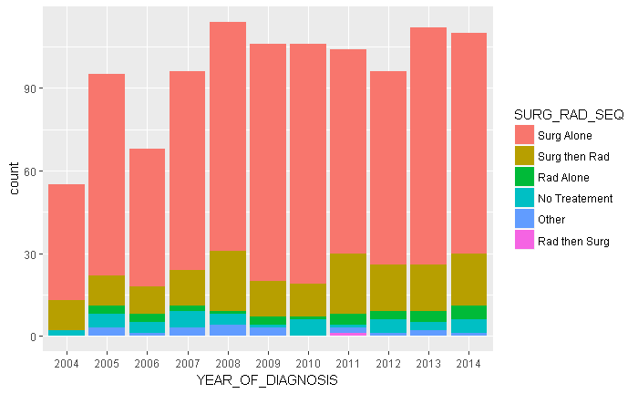

```r
data %>%
    ggplot(aes(x = YEAR_OF_DIAGNOSIS)) +
    geom_histogram(stat = "count", aes(fill = SURG_RAD_SEQ))
```

```
Ignoring unknown parameters: binwidth, bins, pad
```

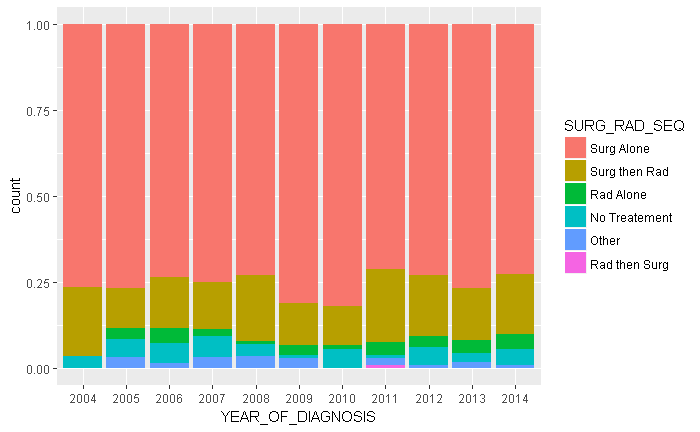

```r
data %>%
    ggplot(aes(x = YEAR_OF_DIAGNOSIS)) +
    geom_histogram(stat = "count", aes(fill = SURG_RAD_SEQ), position = "fill")
```

## Treatment by region

```r
p_table(data,
        vars = c("SURG_RAD_SEQ"),
        strata = c("FACILITY_LOCATION_F"))
```

```
|                 |     level     | New England | Middle Atlantic | South Atlantic | East North Central | East South Central | West North Central | West South Central | Mountain  |  Pacific  |   p   | test |
|:----------------|:-------------:|:-----------:|:---------------:|:--------------:|:------------------:|:------------------:|:------------------:|:------------------:|:---------:|:---------:|:-----:|:----:|
|n                |               |     48      |       194       |      229       |        162         |         77         |         76         |         67         |    43     |    90     |       |      |
|SURG_RAD_SEQ (%) |  Surg Alone   |  40 (83.3)  |   147 (75.8)    |   174 (76.0)   |     129 (79.6)     |     59 (76.6)      |     61 (80.3)      |     43 (64.2)      | 36 (83.7) | 68 (75.6) | 0.383 |      |
|                 | Surg then Rad |  5 (10.4)   |    33 (17.0)    |   34 (14.8)    |     21 (13.0)      |     10 (13.0)      |     12 (15.8)      |     15 (22.4)      | 3 ( 7.0)  | 14 (15.6) |       |      |
|                 |   Rad Alone   |  2 ( 4.2)   |    5 ( 2.6)     |    4 ( 1.7)    |      5 ( 3.1)      |      3 ( 3.9)      |      0 ( 0.0)      |      3 ( 4.5)      | 0 ( 0.0)  | 4 ( 4.4)  |       |      |
|                 | No Treatement |  1 ( 2.1)   |    3 ( 1.5)     |   11 ( 4.8)    |      6 ( 3.7)      |      3 ( 3.9)      |      2 ( 2.6)      |      4 ( 6.0)      | 2 ( 4.7)  | 4 ( 4.4)  |       |      |
|                 |     Other     |  0 ( 0.0)   |    6 ( 3.1)     |    6 ( 2.6)    |      1 ( 0.6)      |      2 ( 2.6)      |      0 ( 0.0)      |      2 ( 3.0)      | 2 ( 4.7)  | 0 ( 0.0)  |       |      |
|                 | Rad then Surg |  0 ( 0.0)   |    0 ( 0.0)     |    0 ( 0.0)    |      0 ( 0.0)      |      0 ( 0.0)      |      1 ( 1.3)      |      0 ( 0.0)      | 0 ( 0.0)  | 0 ( 0.0)  |       |      |
```

## Demographics by region

```r
p_table(data,
        vars = c("AGE_F", "RACE_F", "SEX_F", "INCOME_F", "EDUCATION_F", "INSURANCE_F", "U_R_F"),
        strata = c("FACILITY_LOCATION_F"))
```

```
|                |       level       | New England | Middle Atlantic | South Atlantic | East North Central | East South Central | West North Central | West South Central | Mountain  |  Pacific  |   p    | test |
|:---------------|:-----------------:|:-----------:|:---------------:|:--------------:|:------------------:|:------------------:|:------------------:|:------------------:|:---------:|:---------:|:------:|:----:|
|n               |                   |     48      |       194       |      229       |        162         |         77         |         76         |         67         |    43     |    90     |        |      |
|AGE_F (%)       |      (0,54]       |  15 (31.2)  |    59 (30.4)    |   68 (29.7)    |     42 (25.9)      |     20 (26.0)      |     19 (25.0)      |     26 (38.8)      | 6 (14.0)  | 24 (26.7) | 0.651  |      |
|                |      (54,64]      |  11 (22.9)  |    59 (30.4)    |   59 (25.8)    |     48 (29.6)      |     25 (32.5)      |     22 (28.9)      |     21 (31.3)      | 13 (30.2) | 22 (24.4) |        |      |
|                |      (64,74]      |  13 (27.1)  |    40 (20.6)    |   61 (26.6)    |     48 (29.6)      |     19 (24.7)      |     18 (23.7)      |     12 (17.9)      | 13 (30.2) | 23 (25.6) |        |      |
|                |     (74,100]      |  9 (18.8)   |    36 (18.6)    |   41 (17.9)    |     24 (14.8)      |     13 (16.9)      |     17 (22.4)      |      8 (11.9)      | 11 (25.6) | 21 (23.3) |        |      |
|RACE_F (%)      |       White       |  42 (87.5)  |   138 (71.1)    |   142 (62.0)   |     126 (77.8)     |     51 (66.2)      |     61 (80.3)      |     34 (50.7)      | 42 (97.7) | 73 (81.1) | <0.001 |      |
|                |       Black       |  5 (10.4)   |    44 (22.7)    |   79 (34.5)    |     32 (19.8)      |     23 (29.9)      |     14 (18.4)      |     32 (47.8)      | 0 ( 0.0)  | 5 ( 5.6)  |        |      |
|                |     Other/Unk     |  1 ( 2.1)   |    8 ( 4.1)     |    7 ( 3.1)    |      3 ( 1.9)      |      1 ( 1.3)      |      1 ( 1.3)      |      0 ( 0.0)      | 1 ( 2.3)  | 11 (12.2) |        |      |
|                |       Asian       |  0 ( 0.0)   |    4 ( 2.1)     |    1 ( 0.4)    |      1 ( 0.6)      |      2 ( 2.6)      |      0 ( 0.0)      |      1 ( 1.5)      | 0 ( 0.0)  | 1 ( 1.1)  |        |      |
|SEX_F (%)       |       Male        |  15 (31.2)  |    56 (28.9)    |   77 (33.6)    |     54 (33.3)      |     24 (31.2)      |     32 (42.1)      |     20 (29.9)      | 15 (34.9) | 33 (36.7) | 0.704  |      |
|                |      Female       |  33 (68.8)  |   138 (71.1)    |   152 (66.4)   |     108 (66.7)     |     53 (68.8)      |     44 (57.9)      |     47 (70.1)      | 28 (65.1) | 57 (63.3) |        |      |
|INCOME_F (%)    | Less than $38,000 |  8 (16.7)   |    40 (20.6)    |   59 (25.8)    |     42 (25.9)      |     35 (45.5)      |      7 ( 9.2)      |     22 (32.8)      | 3 ( 7.0)  | 5 ( 5.6)  | <0.001 |      |
|                | $38,000 - $47,999 |  6 (12.5)   |    26 (13.4)    |   68 (29.7)    |     47 (29.0)      |     21 (27.3)      |     26 (34.2)      |     18 (26.9)      | 7 (16.3)  | 19 (21.1) |        |      |
|                | $48,000 - $62,999 |  15 (31.2)  |    41 (21.1)    |   41 (17.9)    |     31 (19.1)      |     13 (16.9)      |     29 (38.2)      |     15 (22.4)      | 19 (44.2) | 29 (32.2) |        |      |
|                |     $63,000 +     |  19 (39.6)  |    87 (44.8)    |   60 (26.2)    |     42 (25.9)      |      8 (10.4)      |     14 (18.4)      |     12 (17.9)      | 14 (32.6) | 36 (40.0) |        |      |
|                |        NA         |  0 ( 0.0)   |    0 ( 0.0)     |    1 ( 0.4)    |      0 ( 0.0)      |      0 ( 0.0)      |      0 ( 0.0)      |      0 ( 0.0)      | 0 ( 0.0)  | 1 ( 1.1)  |        |      |
|EDUCATION_F (%) |    21% or more    |  14 (29.2)  |    39 (20.1)    |   54 (23.6)    |     18 (11.1)      |     31 (40.3)      |     10 (13.2)      |     26 (38.8)      | 1 ( 2.3)  | 12 (13.3) | <0.001 |      |
|                |    13 - 20.9%     |  4 ( 8.3)   |    39 (20.1)    |   85 (37.1)    |     50 (30.9)      |     26 (33.8)      |     16 (21.1)      |     17 (25.4)      | 8 (18.6)  | 23 (25.6) |        |      |
|                |     7 - 12.9%     |  20 (41.7)  |    73 (37.6)    |   56 (24.5)    |     62 (38.3)      |     15 (19.5)      |     31 (40.8)      |     15 (22.4)      | 17 (39.5) | 31 (34.4) |        |      |
|                |   Less than 7%    |  10 (20.8)  |    43 (22.2)    |   33 (14.4)    |     32 (19.8)      |      5 ( 6.5)      |     19 (25.0)      |      9 (13.4)      | 17 (39.5) | 23 (25.6) |        |      |
```

[output cut: 11 more lines]

## Treatment by tumor size

```r
p_table(data,
        vars = c("SURG_RAD_SEQ"),
        strata = c("T_SIZE"))
```

```
|                 |     level     |   < 1 cm   |   1-2 cm   |   2-3 cm   |  3-4 cm   |  4-5 cm   |  5-6 cm   |   >6 cm   |  NA_unk   |   p    | test |
|:----------------|:-------------:|:----------:|:----------:|:----------:|:---------:|:---------:|:---------:|:---------:|:---------:|:------:|:----:|
|n                |               |    126     |    361     |    256     |    113    |    43     |    19     |    25     |    119    |        |      |
|SURG_RAD_SEQ (%) |  Surg Alone   | 114 (90.5) | 299 (82.8) | 192 (75.0) | 74 (65.5) | 20 (46.5) | 10 (52.6) | 10 (40.0) | 84 (70.6) | <0.001 |      |
|                 | Surg then Rad | 11 ( 8.7)  | 50 (13.9)  | 49 (19.1)  | 27 (23.9) | 15 (34.9) | 1 ( 5.3)  | 5 (20.0)  | 9 ( 7.6)  |        |      |
|                 |   Rad Alone   |  0 ( 0.0)  |  2 ( 0.6)  |  4 ( 1.6)  | 2 ( 1.8)  | 5 (11.6)  | 3 (15.8)  | 6 (24.0)  | 7 ( 5.9)  |        |      |
|                 | No Treatement |  0 ( 0.0)  |  5 ( 1.4)  |  7 ( 2.7)  | 7 ( 6.2)  | 1 ( 2.3)  | 3 (15.8)  | 3 (12.0)  | 16 (13.4) |        |      |
|                 |     Other     |  1 ( 0.8)  |  5 ( 1.4)  |  4 ( 1.6)  | 3 ( 2.7)  | 2 ( 4.7)  | 2 (10.5)  | 0 ( 0.0)  | 3 ( 2.5)  |        |      |
|                 | Rad then Surg |  0 ( 0.0)  |  0 ( 0.0)  |  0 ( 0.0)  | 0 ( 0.0)  | 0 ( 0.0)  | 0 ( 0.0)  | 1 ( 4.0)  | 0 ( 0.0)  |        |      |
```

```
Ignoring unknown parameters: binwidth, bins, pad
```

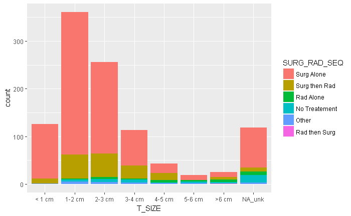

```r
data %>%
    ggplot(aes(x = T_SIZE)) +
    geom_histogram(stat = "count", aes(fill = SURG_RAD_SEQ))
```

```
Ignoring unknown parameters: binwidth, bins, pad
```

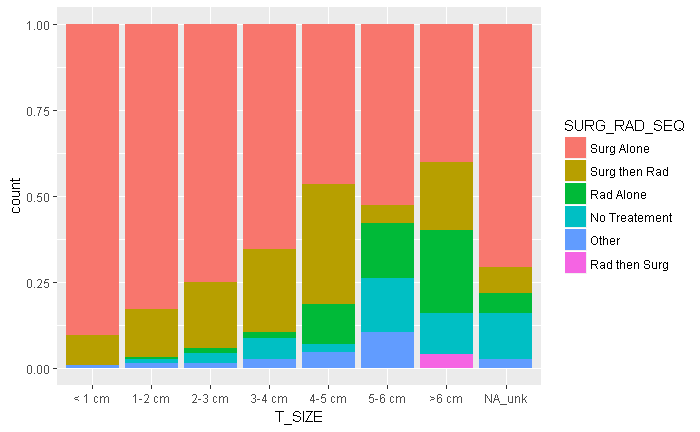

```r
data %>%
    ggplot(aes(x = T_SIZE)) +
    geom_histogram(stat = "count", aes(fill = SURG_RAD_SEQ), position = "fill")
```

# Tumor size by year

Limited to below 10 cm to exclude recording errors

```r
data <- data %>%
        mutate(TUMOR_SIZE_LIM = ifelse(TUMOR_SIZE < 100,
                                       TUMOR_SIZE,
                                        NA)) %>%
        mutate(T_SIZE_LIM = fct_recode(T_SIZE,
                                       NULL = "NA_unk"))
p_table(data,
        vars = c("TUMOR_SIZE", "TUMOR_SIZE_LIM", "T_SIZE_LIM"),
        strata = c("YEAR_OF_DIAGNOSIS"))
```

```
|                           | level  |      2004       |      2005       |      2006       |      2007       |      2008       |      2009       |      2010       |      2011       |      2012       |      2013       |      2014       |   p   | test |
|:--------------------------|:------:|:---------------:|:---------------:|:---------------:|:---------------:|:---------------:|:---------------:|:---------------:|:---------------:|:---------------:|:---------------:|:---------------:|:-----:|:----:|
|n                          |        |       55        |       95        |       68        |       96        |       114       |       106       |       106       |       104       |       96        |       112       |       110       |       |      |
|TUMOR_SIZE (mean (sd))     |        | 197.60 (381.09) | 215.40 (393.07) | 207.46 (387.37) | 185.50 (365.98) | 141.08 (322.32) | 123.20 (299.47) | 205.36 (383.54) | 153.80 (333.68) | 143.93 (324.33) | 124.81 (303.63) | 126.73 (306.74) | 0.373 |      |
|TUMOR_SIZE_LIM (mean (sd)) |        |  19.67 (12.05)  |  19.97 (11.98)  |  20.62 (14.13)  |  22.80 (15.28)  |  21.09 (12.59)  |  21.86 (13.02)  |  21.37 (13.80)  |  22.92 (13.71)  |  22.07 (13.32)  |  20.18 (12.31)  |  19.99 (14.77)  | 0.821 |      |
|T_SIZE_LIM (%)             | < 1 cm |    4 ( 7.3)     |    9 ( 9.5)     |    8 (11.8)     |    8 ( 8.3)     |    17 (14.9)    |    6 ( 5.7)     |    18 (17.0)    |    9 ( 8.7)     |    8 ( 8.3)     |    17 (15.2)    |    22 (20.0)    | 0.296 |      |
|                           | 1-2 cm |    21 (38.2)    |    35 (36.8)    |    24 (35.3)    |    31 (32.3)    |    27 (23.7)    |    43 (40.6)    |    29 (27.4)    |    41 (39.4)    |    33 (34.4)    |    40 (35.7)    |    37 (33.6)    |       |      |
|                           | 2-3 cm |    15 (27.3)    |    22 (23.2)    |    11 (16.2)    |    19 (19.8)    |    36 (31.6)    |    29 (27.4)    |    25 (23.6)    |    26 (25.0)    |    26 (27.1)    |    25 (22.3)    |    22 (20.0)    |       |      |
|                           | 3-4 cm |    4 ( 7.3)     |    8 ( 8.4)     |    11 (16.2)    |    10 (10.4)    |    16 (14.0)    |    9 ( 8.5)     |    11 (10.4)    |    8 ( 7.7)     |    14 (14.6)    |    14 (12.5)    |    8 ( 7.3)     |       |      |
|                           | 4-5 cm |    1 ( 1.8)     |    3 ( 3.2)     |    2 ( 2.9)     |    5 ( 5.2)     |    4 ( 3.5)     |    3 ( 2.8)     |    4 ( 3.8)     |    8 ( 7.7)     |    3 ( 3.1)     |    6 ( 5.4)     |    4 ( 3.6)     |       |      |
|                           | 5-6 cm |    0 ( 0.0)     |    1 ( 1.1)     |    0 ( 0.0)     |    4 ( 4.2)     |    1 ( 0.9)     |    2 ( 1.9)     |    3 ( 2.8)     |    4 ( 3.8)     |    1 ( 1.0)     |    0 ( 0.0)     |    3 ( 2.7)     |       |      |
|                           | >6 cm  |    1 ( 1.8)     |    2 ( 2.1)     |    1 ( 1.5)     |    3 ( 3.1)     |    1 ( 0.9)     |    4 ( 3.8)     |    3 ( 2.8)     |    2 ( 1.9)     |    3 ( 3.1)     |    2 ( 1.8)     |    3 ( 2.7)     |       |      |
|                           |   NA   |    9 (16.4)     |    15 (15.8)    |    11 (16.2)    |    16 (16.7)    |    12 (10.5)    |    10 ( 9.4)    |    13 (12.3)    |    6 ( 5.8)     |    8 ( 8.3)     |    8 ( 7.1)     |    11 (10.0)    |       |      |
```

```r
data %>%
        mutate(YEAR = as.numeric(as.character(YEAR_OF_DIAGNOSIS))) %>%
        lm(TUMOR_SIZE_LIM ~ YEAR,
              data = .) %>%
        summary()
```

```
Call:
lm(formula = TUMOR_SIZE_LIM ~ YEAR, data = .)

Residuals:
    Min      1Q  Median      3Q     Max
-20.203  -9.229  -2.203   4.811  72.837

Coefficients:
             Estimate Std. Error t value Pr(>|t|)
(Intercept)  -5.02325  295.92558  -0.017    0.986
YEAR          0.01305    0.14726   0.089    0.929

Residual standard error: 13.4 on 907 degrees of freedom
  (153 observations deleted due to missingness)
Multiple R-squared:  8.664e-06, Adjusted R-squared:  -0.001094
F-statistic: 0.007858 on 1 and 907 DF,  p-value: 0.9294
```

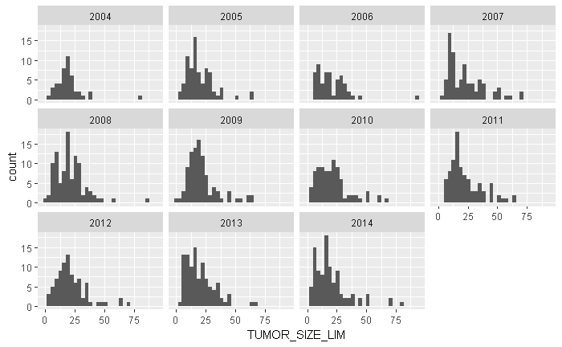

```r
data %>%
    ggplot(aes(x = TUMOR_SIZE_LIM)) +
    geom_histogram() +
    facet_wrap(~ YEAR_OF_DIAGNOSIS)
```

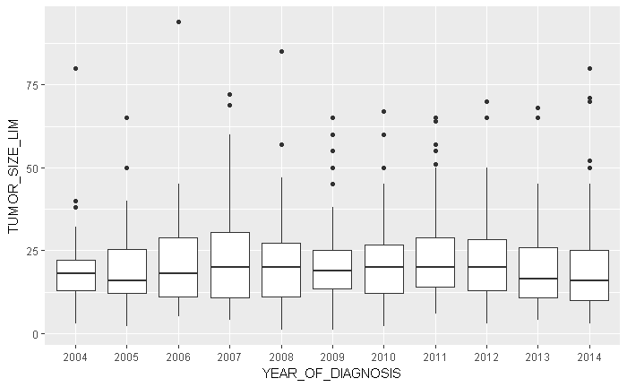

```r
data %>%
    ggplot(aes(x = YEAR_OF_DIAGNOSIS, y = TUMOR_SIZE_LIM)) +
    geom_boxplot()
```

```
Ignoring unknown parameters: binwidth, bins, pad
```

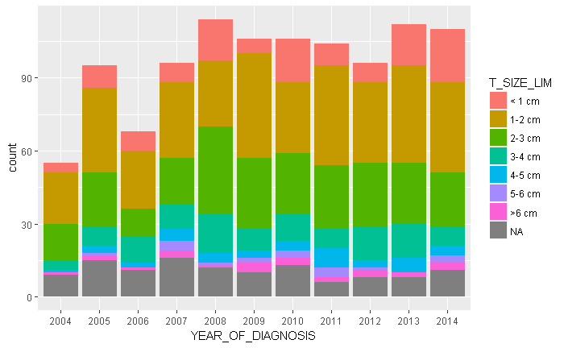

```r
data %>%
        ggplot(aes(x = YEAR_OF_DIAGNOSIS)) +
        geom_histogram(stat = "count",
                       aes(fill = T_SIZE_LIM))
```

```
Ignoring unknown parameters: binwidth, bins, pad
```

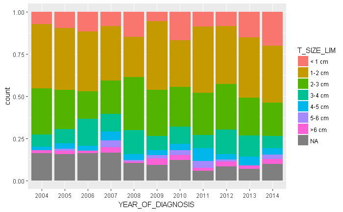

```r
data %>%
        ggplot(aes(x = YEAR_OF_DIAGNOSIS)) +
        geom_histogram(stat = "count",
                       aes(fill = T_SIZE_LIM),
                       position = "fill")
```

# Treatment models

```r
data <- data %>%
        mutate(FACILITY_LOCATION_F = fct_relevel(FACILITY_LOCATION_F,
                                             "New England")) %>%
        mutate(SURG_TX = case_when(SURGERY_YN == "Yes" ~ TRUE,
                                   SURGERY_YN == "No" ~ FALSE,
                                   TRUE ~ NA)) %>%
        mutate(YEAR_OF_DIAGNOSIS = fct_relevel(YEAR_OF_DIAGNOSIS,
                                               "2014"))
fit_surg <- glm(SURG_TX ~ AGE + SEX + CDCC_TOTAL + T_SIZE + FACILITY_TYPE_F + FACILITY_LOCATION_F +
                        YEAR_OF_DIAGNOSIS,
                family = "binomial",
                data = data)
summary(fit_surg)
```

```
Call:
glm(formula = SURG_TX ~ AGE + SEX + CDCC_TOTAL + T_SIZE + FACILITY_TYPE_F +
    FACILITY_LOCATION_F + YEAR_OF_DIAGNOSIS, family = "binomial",
    data = data)

Deviance Residuals:
    Min       1Q   Median       3Q      Max
-3.3996   0.0975   0.1859   0.3216   1.2880

Coefficients:
                                               Estimate Std. Error z value Pr(>|z|)
(Intercept)                                   22.515479 954.926440   0.024 0.981189
AGE                                           -0.042494   0.012570  -3.381 0.000723 ***
SEX2                                           0.366860   0.310936   1.180 0.238058
CDCC_TOTAL1                                    0.003188   0.420823   0.008 0.993956
CDCC_TOTAL2                                   -0.576118   0.756736  -0.761 0.446466
CDCC_TOTAL3                                   -1.373016   1.021085  -1.345 0.178734
T_SIZE1-2 cm                                 -15.352130 954.925318  -0.016 0.987173
T_SIZE2-3 cm                                 -16.189805 954.925286  -0.017 0.986473
T_SIZE3-4 cm                                 -16.857009 954.925313  -0.018 0.985916
T_SIZE4-5 cm                                 -17.533230 954.925374  -0.018 0.985351
T_SIZE5-6 cm                                 -18.521349 954.925386  -0.019 0.984526
T_SIZE>6 cm                                  -18.911900 954.925368  -0.020 0.984199
T_SIZENA_unk                                 -17.845289 954.925270  -0.019 0.985090
FACILITY_TYPE_FComprehensive Comm Ca Program  -1.850290   1.113511  -1.662 0.096579 .
FACILITY_TYPE_FAcademic/Research Program      -1.097145   1.105298  -0.993 0.320893
FACILITY_TYPE_FIntegrated Network Ca Program  -0.901420   1.261994  -0.714 0.475053
FACILITY_LOCATION_FMiddle Atlantic             0.668241   0.764571   0.874 0.382114
FACILITY_LOCATION_FSouth Atlantic              0.370023   0.732323   0.505 0.613367
FACILITY_LOCATION_FEast North Central          0.171585   0.748426   0.229 0.818666
FACILITY_LOCATION_FEast South Central          0.105798   0.829618   0.128 0.898524
FACILITY_LOCATION_FWest North Central          1.438184   1.003308   1.433 0.151731
FACILITY_LOCATION_FWest South Central          0.017370   0.844426   0.021 0.983589
FACILITY_LOCATION_FMountain                    0.797331   1.045202   0.763 0.445554
FACILITY_LOCATION_FPacific                    -0.057542   0.775909  -0.074 0.940882
YEAR_OF_DIAGNOSIS2004                          1.531061   1.153143   1.328 0.184268
YEAR_OF_DIAGNOSIS2005                         -0.172597   0.599897  -0.288 0.773568
YEAR_OF_DIAGNOSIS2006                          0.453315   0.731519   0.620 0.535462
YEAR_OF_DIAGNOSIS2007                          0.998077   0.682634   1.462 0.143715
YEAR_OF_DIAGNOSIS2008                          0.539999   0.660068   0.818 0.413303
YEAR_OF_DIAGNOSIS2009                          1.500864   0.773172   1.941 0.052237 .
YEAR_OF_DIAGNOSIS2010                          0.445715   0.621549   0.717 0.473310
YEAR_OF_DIAGNOSIS2011                          0.486914   0.675814   0.720 0.471226
YEAR_OF_DIAGNOSIS2012                          0.128434   0.629163   0.204 0.838248
YEAR_OF_DIAGNOSIS2013                          0.305778   0.631250   0.484 0.628101
---
Signif. codes:  0 *** 0.001 ** 0.01 * 0.05 . 0.1   1

(Dispersion parameter for binomial family taken to be 1)

    Null deviance: 457.01  on 980  degrees of freedom
Residual deviance: 334.37  on 947  degrees of freedom
  (81 observations deleted due to missingness)
AIC: 402.37

Number of Fisher Scoring iterations: 18
```

```r
exp(cbind("Odds ratio" = coef(fit_surg), confint.default(fit_surg, level = 0.95)))
```

```
                                               Odds ratio      2.5 %     97.5 %
(Intercept)                                  6.002720e+09 0.00000000        Inf
AGE                                          9.583960e-01 0.93507307  0.9823006
SEX2                                         1.443196e+00 0.78461359  2.6545728
CDCC_TOTAL1                                  1.003193e+00 0.43972327  2.2887040
CDCC_TOTAL2                                  5.620761e-01 0.12754420  2.4770205
CDCC_TOTAL3                                  2.533417e-01 0.03424191  1.8743707
T_SIZE1-2 cm                                 2.151071e-07 0.00000000        Inf
T_SIZE2-3 cm                                 9.308010e-08 0.00000000        Inf
T_SIZE3-4 cm                                 4.776325e-08 0.00000000        Inf
T_SIZE4-5 cm                                 2.428931e-08 0.00000000        Inf
T_SIZE5-6 cm                                 9.042330e-09 0.00000000        Inf
T_SIZE>6 cm                                  6.118800e-09 0.00000000        Inf
T_SIZENA_unk                                 1.777827e-08 0.00000000        Inf
FACILITY_TYPE_FComprehensive Comm Ca Program 1.571915e-01 0.01772582  1.3939648
FACILITY_TYPE_FAcademic/Research Program     3.338226e-01 0.03825464  2.9130465
FACILITY_TYPE_FIntegrated Network Ca Program 4.059928e-01 0.03422214  4.8164766
FACILITY_LOCATION_FMiddle Atlantic           1.950802e+00 0.43592271  8.7300559
FACILITY_LOCATION_FSouth Atlantic            1.447768e+00 0.34462330  6.0820947
FACILITY_LOCATION_FEast North Central        1.187185e+00 0.27381481  5.1473056
FACILITY_LOCATION_FEast South Central        1.111598e+00 0.21866324  5.6509254
FACILITY_LOCATION_FWest North Central        4.213037e+00 0.58962815 30.1031765
FACILITY_LOCATION_FWest South Central        1.017522e+00 0.19443155  5.3250117
FACILITY_LOCATION_FMountain                  2.219608e+00 0.28615350 17.2168481
FACILITY_LOCATION_FPacific                   9.440820e-01 0.20632643  4.3198093
YEAR_OF_DIAGNOSIS2004                        4.623077e+00 0.48236344 44.3085923
YEAR_OF_DIAGNOSIS2005                        8.414769e-01 0.25966209  2.7269417
YEAR_OF_DIAGNOSIS2006                        1.573520e+00 0.37514781  6.5999701
YEAR_OF_DIAGNOSIS2007                        2.713059e+00 0.71186950 10.3399386
YEAR_OF_DIAGNOSIS2008                        1.716005e+00 0.47061702  6.2570447
YEAR_OF_DIAGNOSIS2009                        4.485564e+00 0.98558078 20.4146469
YEAR_OF_DIAGNOSIS2010                        1.561607e+00 0.46185755  5.2800156
YEAR_OF_DIAGNOSIS2011                        1.627287e+00 0.43272328  6.1195294
YEAR_OF_DIAGNOSIS2012                        1.137046e+00 0.33130948  3.9023160
YEAR_OF_DIAGNOSIS2013                        1.357681e+00 0.39398268  4.6786261
```

# Kaplan Meier Analysis

```r
uni_var <- function(test_var, data_imp) {

        cat("_________________________________________________")
        cat("\n")
        cat("   \n##", test_var)
        cat("\n")
        cat("_________________________________________________")
        cat("\n")

        f <- as.formula(paste("Surv(DX_LASTCONTACT_DEATH_MONTHS, PUF_VITAL_STATUS == 0)",
                              as.name(test_var),
                              sep = " ~ " ))

        data_imp_2 <- deparse(substitute(data_imp))
        km_fit <- do.call("survfit", list(formula = f, data = as.name(data_imp_2)))
        print(km_fit)
        cat("\n")
        print(summary(km_fit, times = c(12, 24, 36, 48, 60, 120)))
        cat("\n")
        cat("\n")
        cat("\n")
        cat("   \n## Univariable Cox Proportional Hazard Model for: ", test_var)
        cat("\n")
        cat("\n")
        n_levels <- nlevels(data_imp[[test_var]])
        if(n_levels == 1){
                print("Only one level, no Cox model performed")
                cat("\n")
        } else {
                cox_fit <- do.call("coxph", list(formula = f, data = as.name(data_imp_2)))
                print(summary(cox_fit))
                cat("\n")

                do.call("ggforest",
                         list(model = cox_fit, data = as.name(data_imp_2)))
        }
        cat("\n")
        cat("\n")
        cat("\n")
        cat("   \n## Unadjusted Kaplan Meier Overall Survival Curve for: ", test_var)
        p <- do.call("ggsurvplot",
                     list(fit = km_fit, data = as.name(data_imp_2),
                          palette = "jco", censor = FALSE, legend = "right",
                          linetype = "strata", xlab = "Time (Months)"))
        print(p)
}
```

## All

```r
uni_var(test_var = "All", data_imp = data)
```

[output not shown]

```
_________________________________________________

## All
_________________________________________________
Call: survfit(formula = Surv(DX_LASTCONTACT_DEATH_MONTHS, PUF_VITAL_STATUS ==
    0) ~ All, data = data)

      n  events  median 0.95LCL 0.95UCL
   1062     163      NA     148      NA

Call: survfit(formula = Surv(DX_LASTCONTACT_DEATH_MONTHS, PUF_VITAL_STATUS ==
    0) ~ All, data = data)

 time n.risk n.event survival std.err lower 95% CI upper 95% CI
   12    993      24    0.977 0.00465        0.968        0.986
   24    874      24    0.952 0.00680        0.939        0.965
   36    733      29    0.918 0.00903        0.900        0.936
   48    608      17    0.895 0.01039        0.875        0.915
   60    501      17    0.868 0.01195        0.845        0.892
  120     87      45    0.714 0.02581        0.665        0.766




## Univariable Cox Proportional Hazard Model for:  All

[1] "Only one level, no Cox model performed"





## Unadjusted Kaplan Meier Overall Survival Curve for:  All
```

## Facility Type

```
_________________________________________________

## FACILITY_TYPE_F
_________________________________________________
Call: survfit(formula = Surv(DX_LASTCONTACT_DEATH_MONTHS, PUF_VITAL_STATUS ==
    0) ~ FACILITY_TYPE_F, data = data)

   76 observations deleted due to missingness
                                                n events median 0.95LCL 0.95UCL
FACILITY_TYPE_F=Community Cancer Program       44      4     NA      NA      NA
FACILITY_TYPE_F=Comprehensive Comm Ca Program 255     50     NA     124      NA
FACILITY_TYPE_F=Academic/Research Program     596     96    148     148      NA
FACILITY_TYPE_F=Integrated Network Ca Program  91      8     NA      NA      NA

Call: survfit(formula = Surv(DX_LASTCONTACT_DEATH_MONTHS, PUF_VITAL_STATUS ==
    0) ~ FACILITY_TYPE_F, data = data)

76 observations deleted due to missingness
                FACILITY_TYPE_F=Community Cancer Program
 time n.risk n.event survival std.err lower 95% CI upper 95% CI
   12     41       1    0.977  0.0225        0.934            1
   24     38       0    0.977  0.0225        0.934            1
   36     31       2    0.923  0.0429        0.843            1
   48     27       0    0.923  0.0429        0.843            1
   60     22       0    0.923  0.0429        0.843            1
  120      4       1    0.769  0.1449        0.532            1

                FACILITY_TYPE_F=Comprehensive Comm Ca Program
 time n.risk n.event survival std.err lower 95% CI upper 95% CI
   12    234       8    0.968  0.0113        0.946        0.990
   24    200       8    0.932  0.0164        0.900        0.965
   36    166      11    0.877  0.0223        0.834        0.922
   48    135       8    0.831  0.0264        0.781        0.885
   60    115       3    0.811  0.0281        0.758        0.869
  120     18      11    0.619  0.0607        0.511        0.751

                FACILITY_TYPE_F=Academic/Research Program
 time n.risk n.event survival std.err lower 95% CI upper 95% CI
   12    561      14    0.976  0.0063        0.964        0.989
   24    498      15    0.949  0.0093        0.931        0.967
```

[output cut: 29 more lines]

```
FACILITY_TYPE_FAcademic/Research Program     0.6134    1.8468   0.5105 1.202   0.2295
FACILITY_TYPE_FIntegrated Network Ca Program 0.2395    1.2706   0.6133 0.390   0.6962
---
Signif. codes:  0 *** 0.001 ** 0.01 * 0.05 . 0.1   1

                                             exp(coef) exp(-coef) lower .95 upper .95
FACILITY_TYPE_FComprehensive Comm Ca Program     2.420     0.4132    0.8735     6.704
FACILITY_TYPE_FAcademic/Research Program         1.847     0.5415    0.6790     5.023
FACILITY_TYPE_FIntegrated Network Ca Program     1.271     0.7870    0.3819     4.227

Concordance= 0.558  (se = 0.022 )
Rsquare= 0.006   (max possible= 0.862 )
Likelihood ratio test= 6.32  on 3 df,   p=0.09689
Wald test            = 5.85  on 3 df,   p=0.1189
Score (logrank) test = 6.01  on 3 df,   p=0.1113
```

```
Removed 1 rows containing missing values (geom_errorbar).
```

```
## Unadjusted Kaplan Meier Overall Survival Curve for:  FACILITY_TYPE_F
```

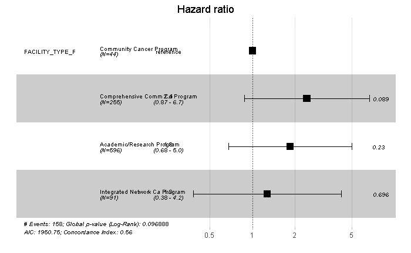

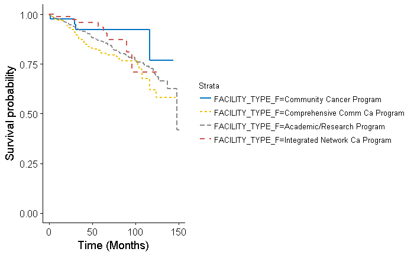

```r
uni_var(test_var = "FACILITY_TYPE_F", data_imp = data)
```

## Facility Location

```
_________________________________________________

## FACILITY_LOCATION_F
_________________________________________________
Call: survfit(formula = Surv(DX_LASTCONTACT_DEATH_MONTHS, PUF_VITAL_STATUS ==
    0) ~ FACILITY_LOCATION_F, data = data)

   76 observations deleted due to missingness
                                         n events median 0.95LCL 0.95UCL
FACILITY_LOCATION_F=New England         48      8     NA     110      NA
FACILITY_LOCATION_F=Middle Atlantic    194     30     NA      NA      NA
FACILITY_LOCATION_F=South Atlantic     229     30     NA     137      NA
FACILITY_LOCATION_F=East North Central 162     27     NA     122      NA
FACILITY_LOCATION_F=East South Central  77     14    148     120      NA
FACILITY_LOCATION_F=West North Central  76     13     NA      NA      NA
FACILITY_LOCATION_F=West South Central  67     12     NA      NA      NA
FACILITY_LOCATION_F=Mountain            43      8     NA      NA      NA
FACILITY_LOCATION_F=Pacific             90     16     NA      NA      NA

Call: survfit(formula = Surv(DX_LASTCONTACT_DEATH_MONTHS, PUF_VITAL_STATUS ==
    0) ~ FACILITY_LOCATION_F, data = data)

76 observations deleted due to missingness
                FACILITY_LOCATION_F=New England
 time n.risk n.event survival std.err lower 95% CI upper 95% CI
   12     42       1    0.977  0.0230        0.933        1.000
   24     38       1    0.953  0.0325        0.891        1.000
   36     33       0    0.953  0.0325        0.891        1.000
   48     29       1    0.924  0.0425        0.844        1.000
   60     26       0    0.924  0.0425        0.844        1.000
  120      8       5    0.608  0.1236        0.408        0.906

                FACILITY_LOCATION_F=Middle Atlantic
 time n.risk n.event survival std.err lower 95% CI upper 95% CI
   12    184       5    0.974  0.0115        0.952        0.997
   24    168       4    0.952  0.0156        0.922        0.983
   36    144       5    0.922  0.0201        0.884        0.962
   48    112       3    0.901  0.0230        0.857        0.947
   60     87       3    0.875  0.0270        0.823        0.929
  120     10      10    0.675  0.0656        0.558        0.817
```

[output cut: 87 more lines]

```
                                      exp(coef) exp(-coef) lower .95 upper .95
FACILITY_LOCATION_FMiddle Atlantic       1.1713     0.8538    0.5339     2.570
FACILITY_LOCATION_FSouth Atlantic        0.9352     1.0693    0.4268     2.049
FACILITY_LOCATION_FEast North Central    1.1076     0.9029    0.5020     2.444
FACILITY_LOCATION_FEast South Central    1.2262     0.8156    0.5139     2.926
FACILITY_LOCATION_FWest North Central    1.2193     0.8202    0.5036     2.952
FACILITY_LOCATION_FWest South Central    1.4354     0.6967    0.5839     3.528
FACILITY_LOCATION_FMountain              1.4937     0.6695    0.5584     3.996
FACILITY_LOCATION_FPacific               1.2851     0.7782    0.5479     3.014

Concordance= 0.551  (se = 0.025 )
Rsquare= 0.003   (max possible= 0.862 )
Likelihood ratio test= 2.92  on 8 df,   p=0.9395
Wald test            = 2.92  on 8 df,   p=0.9395
Score (logrank) test = 2.94  on 8 df,   p=0.9381
```

```
Removed 1 rows containing missing values (geom_errorbar).
```

```
## Unadjusted Kaplan Meier Overall Survival Curve for:  FACILITY_LOCATION_F
```

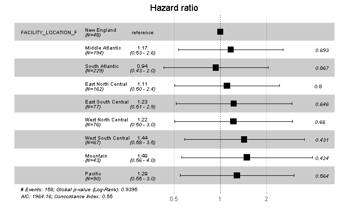

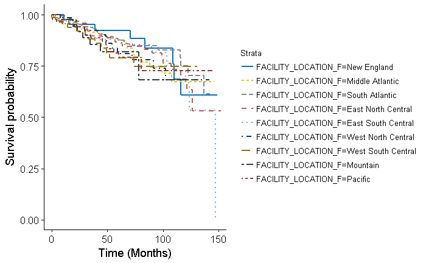

```r
uni_var(test_var = "FACILITY_LOCATION_F", data_imp = data)
```

## Facility Geography

```
_________________________________________________

## FACILITY_GEOGRAPHY
_________________________________________________
Call: survfit(formula = Surv(DX_LASTCONTACT_DEATH_MONTHS, PUF_VITAL_STATUS ==
    0) ~ FACILITY_GEOGRAPHY, data = data)

   76 observations deleted due to missingness
                               n events median 0.95LCL 0.95UCL
FACILITY_GEOGRAPHY=Northeast 242     38     NA      NA      NA
FACILITY_GEOGRAPHY=South     296     42     NA     137      NA
FACILITY_GEOGRAPHY=Midwest   315     54    148     126      NA
FACILITY_GEOGRAPHY=West      133     24     NA      NA      NA

Call: survfit(formula = Surv(DX_LASTCONTACT_DEATH_MONTHS, PUF_VITAL_STATUS ==
    0) ~ FACILITY_GEOGRAPHY, data = data)

76 observations deleted due to missingness
                FACILITY_GEOGRAPHY=Northeast
 time n.risk n.event survival std.err lower 95% CI upper 95% CI
   12    226       6    0.975  0.0102        0.955        0.995
   24    206       5    0.953  0.0139        0.926        0.980
   36    177       5    0.928  0.0174        0.895        0.963
   48    141       4    0.906  0.0202        0.867        0.946
   60    113       3    0.885  0.0231        0.841        0.931
  120     18      15    0.632  0.0649        0.517        0.773

                FACILITY_GEOGRAPHY=South
 time n.risk n.event survival std.err lower 95% CI upper 95% CI
   12    273       9    0.969  0.0101        0.949        0.989
   24    238       6    0.946  0.0136        0.920        0.973
   36    205       5    0.925  0.0163        0.893        0.957
   48    168       8    0.886  0.0206        0.847        0.927
   60    139       5    0.858  0.0235        0.813        0.905
  120     20       7    0.747  0.0521        0.651        0.856

                FACILITY_GEOGRAPHY=Midwest
 time n.risk n.event survival std.err lower 95% CI upper 95% CI
   12    297       4    0.987 0.00648        0.974        1.000
   24    262       9    0.955 0.01219        0.932        0.979
```

[output cut: 27 more lines]

```
                              coef exp(coef) se(coef)      z Pr(>|z|)
FACILITY_GEOGRAPHYSouth   -0.08480   0.91870  0.22414 -0.378    0.705
FACILITY_GEOGRAPHYMidwest  0.02845   1.02886  0.21203  0.134    0.893
FACILITY_GEOGRAPHYWest     0.17599   1.19243  0.26100  0.674    0.500

                          exp(coef) exp(-coef) lower .95 upper .95
FACILITY_GEOGRAPHYSouth      0.9187     1.0885    0.5921     1.425
FACILITY_GEOGRAPHYMidwest    1.0289     0.9720    0.6790     1.559
FACILITY_GEOGRAPHYWest       1.1924     0.8386    0.7149     1.989

Concordance= 0.521  (se = 0.024 )
Rsquare= 0.001   (max possible= 0.862 )
Likelihood ratio test= 1.04  on 3 df,   p=0.7923
Wald test            = 1.06  on 3 df,   p=0.7873
Score (logrank) test = 1.06  on 3 df,   p=0.7865
```

```
Removed 1 rows containing missing values (geom_errorbar).
```

```
## Unadjusted Kaplan Meier Overall Survival Curve for:  FACILITY_GEOGRAPHY
```

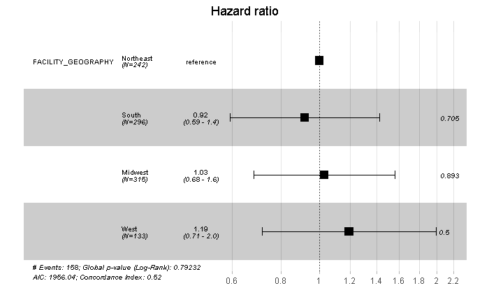

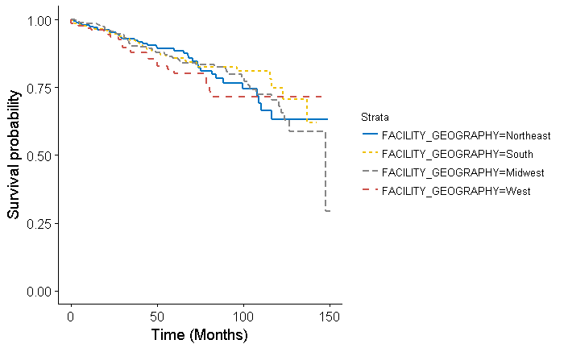

```r
uni_var(test_var = "FACILITY_GEOGRAPHY", data_imp = data)
```

## Age Group

```
_________________________________________________

## AGE_F
_________________________________________________
Call: survfit(formula = Surv(DX_LASTCONTACT_DEATH_MONTHS, PUF_VITAL_STATUS ==
    0) ~ AGE_F, data = data)

                 n events median 0.95LCL 0.95UCL
AGE_F=(0,54]   355     15     NA      NA      NA
AGE_F=(54,64]  280     22     NA      NA      NA
AGE_F=(64,74]  247     55  137.0     116      NA
AGE_F=(74,100] 180     71   96.1      75     116

Call: survfit(formula = Surv(DX_LASTCONTACT_DEATH_MONTHS, PUF_VITAL_STATUS ==
    0) ~ AGE_F, data = data)

                AGE_F=(0,54]
 time n.risk n.event survival std.err lower 95% CI upper 95% CI
   12    341       1    0.997 0.00284        0.992        1.000
   24    306       2    0.991 0.00523        0.981        1.000
   36    268       3    0.981 0.00790        0.965        0.996
   48    225       2    0.973 0.00965        0.954        0.992
   60    195       0    0.973 0.00965        0.954        0.992
  120     36       6    0.922 0.02416        0.876        0.971

                AGE_F=(54,64]
 time n.risk n.event survival std.err lower 95% CI upper 95% CI
   12    262       4    0.986 0.00717        0.972        1.000
   24    228       2    0.977 0.00918        0.959        0.995
   36    188       5    0.954 0.01359        0.928        0.981
   48    158       3    0.938 0.01624        0.907        0.970
   60    132       1    0.932 0.01739        0.898        0.966
  120     22       6    0.863 0.03359        0.799        0.931

                AGE_F=(64,74]
 time n.risk n.event survival std.err lower 95% CI upper 95% CI
   12    232       5    0.979 0.00911        0.962        0.997
   24    199      10    0.935 0.01637        0.903        0.967
   36    165      10    0.883 0.02212        0.841        0.928
   48    138       3    0.866 0.02375        0.821        0.914
```

[output cut: 26 more lines]

```
AGE_F(64,74]   1.7996    6.0473   0.2914 6.175 6.62e-10 ***
AGE_F(74,100]  2.5106   12.3121   0.2846 8.821  < 2e-16 ***
---
Signif. codes:  0 *** 0.001 ** 0.01 * 0.05 . 0.1   1

              exp(coef) exp(-coef) lower .95 upper .95
AGE_F(54,64]      2.143    0.46656     1.112     4.133
AGE_F(64,74]      6.047    0.16536     3.416    10.706
AGE_F(74,100]    12.312    0.08122     7.048    21.508

Concordance= 0.741  (se = 0.024 )
Rsquare= 0.116   (max possible= 0.853 )
Likelihood ratio test= 130.4  on 3 df,   p=0
Wald test            = 107.7  on 3 df,   p=0
Score (logrank) test = 148.1  on 3 df,   p=0
```

```
Removed 1 rows containing missing values (geom_errorbar).
```

```
## Unadjusted Kaplan Meier Overall Survival Curve for:  AGE_F
```

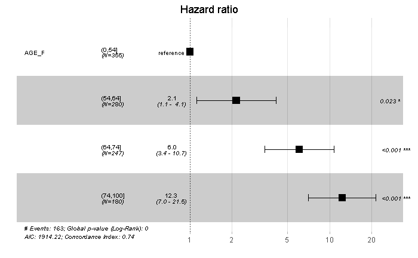

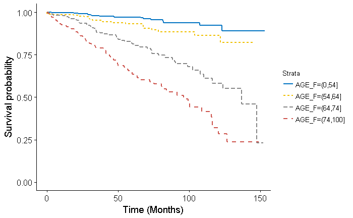

```r
uni_var(test_var = "AGE_F", data_imp = data)
```

## Age Group

```
_________________________________________________

## AGE_40
_________________________________________________
Call: survfit(formula = Surv(DX_LASTCONTACT_DEATH_MONTHS, PUF_VITAL_STATUS ==
    0) ~ AGE_40, data = data)

                  n events median 0.95LCL 0.95UCL
AGE_40=(0,40]    86      5     NA      NA      NA
AGE_40=(40,100] 976    158    148     148      NA

Call: survfit(formula = Surv(DX_LASTCONTACT_DEATH_MONTHS, PUF_VITAL_STATUS ==
    0) ~ AGE_40, data = data)

                AGE_40=(0,40]
 time n.risk n.event survival std.err lower 95% CI upper 95% CI
   12     83       0    1.000  0.0000        1.000        1.000
   24     75       1    0.987  0.0129        0.962        1.000
   36     62       0    0.987  0.0129        0.962        1.000
   48     51       0    0.987  0.0129        0.962        1.000
   60     43       0    0.987  0.0129        0.962        1.000
  120      9       4    0.872  0.0555        0.770        0.988

                AGE_40=(40,100]
 time n.risk n.event survival std.err lower 95% CI upper 95% CI
   12    910      24    0.975 0.00505        0.965        0.985
   24    799      23    0.949 0.00730        0.934        0.963
   36    671      29    0.912 0.00973        0.893        0.931
   48    557      17    0.887 0.01120        0.865        0.909
   60    458      17    0.858 0.01286        0.833        0.883
  120     78      41    0.699 0.02761        0.647        0.756





## Univariable Cox Proportional Hazard Model for:  AGE_40

Call:
coxph(formula = Surv(DX_LASTCONTACT_DEATH_MONTHS, PUF_VITAL_STATUS ==
    0) ~ AGE_40, data = data)

  n= 1062, number of events= 163

                 coef exp(coef) se(coef)     z Pr(>|z|)
AGE_40(40,100] 1.1326    3.1036   0.4553 2.488   0.0129 *
---
Signif. codes:  0 *** 0.001 ** 0.01 * 0.05 . 0.1   1

               exp(coef) exp(-coef) lower .95 upper .95
AGE_40(40,100]     3.104     0.3222     1.272     7.575

Concordance= 0.531  (se = 0.012 )
Rsquare= 0.008   (max possible= 0.853 )
Likelihood ratio test= 8.99  on 1 df,   p=0.002721
Wald test            = 6.19  on 1 df,   p=0.01286
Score (logrank) test = 6.87  on 1 df,   p=0.008775
```

```
Removed 1 rows containing missing values (geom_errorbar).
```

```
## Unadjusted Kaplan Meier Overall Survival Curve for:  AGE_40
```

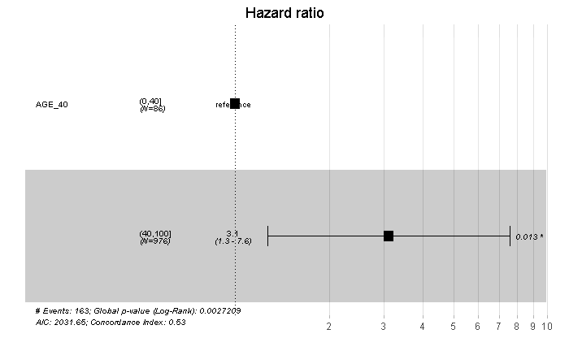

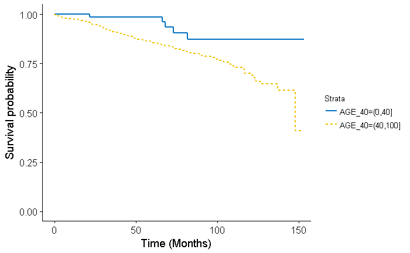

```r
uni_var(test_var = "AGE_40", data_imp = data)
```

## Gender

```
_________________________________________________

## SEX_F
_________________________________________________
Call: survfit(formula = Surv(DX_LASTCONTACT_DEATH_MONTHS, PUF_VITAL_STATUS ==
    0) ~ SEX_F, data = data)

               n events median 0.95LCL 0.95UCL
SEX_F=Male   347     69    148     124      NA
SEX_F=Female 715     94     NA      NA      NA

Call: survfit(formula = Surv(DX_LASTCONTACT_DEATH_MONTHS, PUF_VITAL_STATUS ==
    0) ~ SEX_F, data = data)

                SEX_F=Male
 time n.risk n.event survival std.err lower 95% CI upper 95% CI
   12    317      11    0.967 0.00968        0.949        0.987
   24    270      13    0.925 0.01473        0.897        0.955
   36    229      10    0.888 0.01818        0.853        0.925
   48    186       6    0.862 0.02055        0.823        0.903
   60    155       6    0.832 0.02315        0.788        0.879
  120     29      18    0.650 0.04697        0.564        0.749

                SEX_F=Female
 time n.risk n.event survival std.err lower 95% CI upper 95% CI
   12    676      13    0.982 0.00507        0.972        0.992
   24    604      11    0.964 0.00714        0.951        0.979
   36    504      19    0.932 0.01009        0.912        0.952
   48    422      11    0.910 0.01177        0.887        0.934
   60    346      11    0.885 0.01373        0.858        0.912
  120     58      27    0.743 0.03087        0.685        0.806





## Univariable Cox Proportional Hazard Model for:  SEX_F

Call:
coxph(formula = Surv(DX_LASTCONTACT_DEATH_MONTHS, PUF_VITAL_STATUS ==
    0) ~ SEX_F, data = data)

  n= 1062, number of events= 163

               coef exp(coef) se(coef)      z Pr(>|z|)
SEX_FFemale -0.4763    0.6211   0.1586 -3.003  0.00267 **
---
Signif. codes:  0 *** 0.001 ** 0.01 * 0.05 . 0.1   1

            exp(coef) exp(-coef) lower .95 upper .95
SEX_FFemale    0.6211       1.61    0.4551    0.8475

Concordance= 0.554  (se = 0.02 )
Rsquare= 0.008   (max possible= 0.853 )
Likelihood ratio test= 8.73  on 1 df,   p=0.003138
Wald test            = 9.02  on 1 df,   p=0.002673
Score (logrank) test = 9.19  on 1 df,   p=0.002434
```

```
Removed 1 rows containing missing values (geom_errorbar).
```

```
## Unadjusted Kaplan Meier Overall Survival Curve for:  SEX_F
```

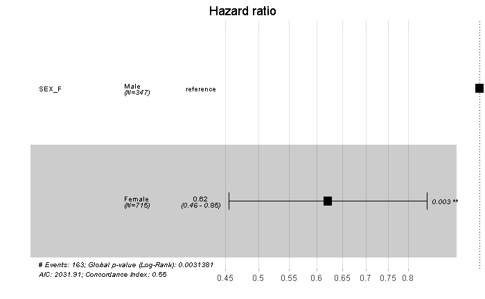

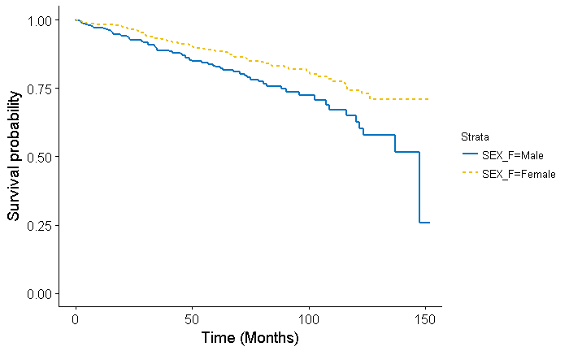

```r
uni_var(test_var = "SEX_F", data_imp = data)
```

## RACE_F

```
_________________________________________________

## RACE_F
_________________________________________________
Call: survfit(formula = Surv(DX_LASTCONTACT_DEATH_MONTHS, PUF_VITAL_STATUS ==
    0) ~ RACE_F, data = data)

                   n events median 0.95LCL 0.95UCL
RACE_F=White     758    121     NA      NA      NA
RACE_F=Black     254     38    148     137      NA
RACE_F=Other/Unk  38      4     NA      NA      NA
RACE_F=Asian      12      0     NA      NA      NA

Call: survfit(formula = Surv(DX_LASTCONTACT_DEATH_MONTHS, PUF_VITAL_STATUS ==
    0) ~ RACE_F, data = data)

                RACE_F=White
 time n.risk n.event survival std.err lower 95% CI upper 95% CI
   12    709      16    0.978 0.00534        0.968        0.989
   24    623      16    0.955 0.00784        0.939        0.970
   36    528      21    0.920 0.01056        0.900        0.941
   48    439      14    0.894 0.01237        0.870        0.919
   60    366      15    0.861 0.01452        0.833        0.890
  120     61      35    0.689 0.03225        0.628        0.755

                RACE_F=Black
 time n.risk n.event survival std.err lower 95% CI upper 95% CI
   12    237       7    0.972  0.0104        0.952        0.993
   24    209       7    0.942  0.0151        0.913        0.972
   36    171       8    0.902  0.0199        0.864        0.942
   48    139       3    0.885  0.0220        0.843        0.929
   60    111       2    0.871  0.0236        0.826        0.919
  120     19       8    0.766  0.0438        0.684        0.857

                RACE_F=Other/Unk
 time n.risk n.event survival std.err lower 95% CI upper 95% CI
   12     35       1    0.974  0.0260        0.924            1
   24     31       1    0.946  0.0373        0.876            1
   36     24       0    0.946  0.0373        0.876            1
   48     21       0    0.946  0.0373        0.876            1
   60     17       0    0.946  0.0373        0.876            1
  120      4       2    0.820  0.0891        0.662            1

                RACE_F=Asian
 time n.risk n.event survival std.err lower 95% CI upper 95% CI
   12     12       0        1       0            1            1
   24     11       0        1       0            1            1
   36     10       0        1       0            1            1
   48      9       0        1       0            1            1
   60      7       0        1       0            1            1
  120      3       0        1       0            1            1





## Univariable Cox Proportional Hazard Model for:  RACE_F
```

```
Loglik converged before variable  3 ; beta may be infinite.
```

```
Call:
coxph(formula = Surv(DX_LASTCONTACT_DEATH_MONTHS, PUF_VITAL_STATUS ==
    0) ~ RACE_F, data = data)

  n= 1062, number of events= 163

                      coef  exp(coef)   se(coef)      z Pr(>|z|)
RACE_FBlack     -2.177e-02  9.785e-01  1.865e-01 -0.117    0.907
RACE_FOther/Unk -4.093e-01  6.641e-01  5.083e-01 -0.805    0.421
RACE_FAsian     -1.605e+01  1.075e-07  1.927e+03 -0.008    0.993

                exp(coef) exp(-coef) lower .95 upper .95
RACE_FBlack     9.785e-01  1.022e+00    0.6789     1.410
RACE_FOther/Unk 6.641e-01  1.506e+00    0.2452     1.798
RACE_FAsian     1.075e-07  9.305e+06    0.0000       Inf

Concordance= 0.506  (se = 0.02 )
Rsquare= 0.005   (max possible= 0.853 )
Likelihood ratio test= 5.62  on 3 df,   p=0.1315
Wald test            = 0.65  on 3 df,   p=0.8847
Score (logrank) test = 3.13  on 3 df,   p=0.3718
```

[output not shown]

```
## Unadjusted Kaplan Meier Overall Survival Curve for:  RACE_F
```

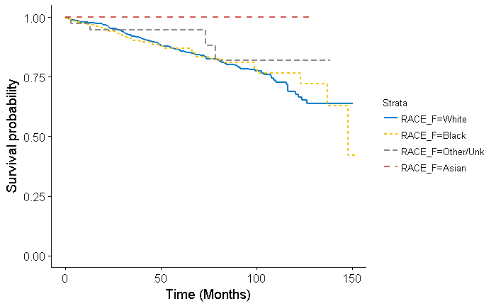

```r
uni_var(test_var = "RACE_F", data_imp = data)
```

## Hispanic

```
_________________________________________________

## HISPANIC
_________________________________________________
Call: survfit(formula = Surv(DX_LASTCONTACT_DEATH_MONTHS, PUF_VITAL_STATUS ==
    0) ~ HISPANIC, data = data)

                   n events median 0.95LCL 0.95UCL
HISPANIC=No      940    145     NA      NA      NA
HISPANIC=Yes      52      6     NA     124      NA
HISPANIC=Unknown  70     12    148      NA      NA

Call: survfit(formula = Surv(DX_LASTCONTACT_DEATH_MONTHS, PUF_VITAL_STATUS ==
    0) ~ HISPANIC, data = data)

                HISPANIC=No
 time n.risk n.event survival std.err lower 95% CI upper 95% CI
   12    881      20    0.978 0.00480        0.969        0.988
   24    777      20    0.955 0.00703        0.941        0.968
   36    648      28    0.918 0.00962        0.899        0.937
   48    534      17    0.892 0.01124        0.870        0.914
   60    439      16    0.863 0.01296        0.838        0.889
  120     75      39    0.712 0.02722        0.661        0.768

                HISPANIC=Yes
 time n.risk n.event survival std.err lower 95% CI upper 95% CI
   12     50       1    0.981  0.0190        0.944            1
   24     40       2    0.941  0.0332        0.878            1
   36     33       0    0.941  0.0332        0.878            1
   48     28       0    0.941  0.0332        0.878            1
   60     23       1    0.905  0.0477        0.816            1
  120      4       1    0.804  0.1038        0.624            1

                HISPANIC=Unknown
 time n.risk n.event survival std.err lower 95% CI upper 95% CI
   12     62       3    0.955  0.0255        0.906        1.000
   24     57       2    0.923  0.0333        0.860        0.990
   36     52       1    0.905  0.0369        0.836        0.981
   48     46       0    0.905  0.0369        0.836        0.981
   60     39       0    0.905  0.0369        0.836        0.981
```

[output cut: 12 more lines]

```
  n= 1062, number of events= 163

                    coef exp(coef) se(coef)      z Pr(>|z|)
HISPANICYes     -0.23316   0.79202  0.41678 -0.559    0.576
HISPANICUnknown -0.05951   0.94222  0.30102 -0.198    0.843

                exp(coef) exp(-coef) lower .95 upper .95
HISPANICYes        0.7920      1.263    0.3499     1.793
HISPANICUnknown    0.9422      1.061    0.5223     1.700

Concordance= 0.507  (se = 0.014 )
Rsquare= 0   (max possible= 0.853 )
Likelihood ratio test= 0.36  on 2 df,   p=0.8337
Wald test            = 0.34  on 2 df,   p=0.8432
Score (logrank) test = 0.34  on 2 df,   p=0.8426
```

```
Removed 1 rows containing missing values (geom_errorbar).
```

```
## Unadjusted Kaplan Meier Overall Survival Curve for:  HISPANIC
```

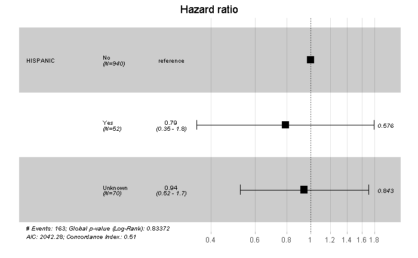

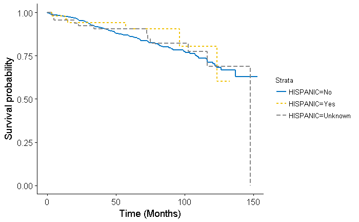

```r
uni_var(test_var = "HISPANIC", data_imp = data)
```

## Insurance Status

```
_________________________________________________

## INSURANCE_F
_________________________________________________
Call: survfit(formula = Surv(DX_LASTCONTACT_DEATH_MONTHS, PUF_VITAL_STATUS ==
    0) ~ INSURANCE_F, data = data)

                               n events median 0.95LCL 0.95UCL
INSURANCE_F=Private          508     25     NA      NA      NA
INSURANCE_F=None              49      5    123     122      NA
INSURANCE_F=Medicaid          59      8     NA     107      NA
INSURANCE_F=Medicare         417    120    116     103      NA
INSURANCE_F=Other Government  10      0     NA      NA      NA
INSURANCE_F=Unknown           19      5     NA     100      NA

Call: survfit(formula = Surv(DX_LASTCONTACT_DEATH_MONTHS, PUF_VITAL_STATUS ==
    0) ~ INSURANCE_F, data = data)

                INSURANCE_F=Private
 time n.risk n.event survival std.err lower 95% CI upper 95% CI
   12    481       8    0.984 0.00561        0.973        0.995
   24    434       1    0.982 0.00602        0.970        0.994
   36    377       2    0.977 0.00689        0.964        0.991
   48    321       5    0.963 0.00913        0.946        0.981
   60    275       1    0.960 0.00965        0.941        0.979
  120     51       7    0.918 0.02042        0.879        0.959

                INSURANCE_F=None
 time n.risk n.event survival std.err lower 95% CI upper 95% CI
   12     44       1    0.978  0.0220        0.936            1
   24     37       0    0.978  0.0220        0.936            1
   36     32       2    0.923  0.0428        0.843            1
   48     26       0    0.923  0.0428        0.843            1
   60     23       0    0.923  0.0428        0.843            1
  120      4       0    0.923  0.0428        0.843            1

                INSURANCE_F=Medicaid
 time n.risk n.event survival std.err lower 95% CI upper 95% CI
   12     56       0    1.000  0.0000        1.000        1.000
   24     46       2    0.962  0.0263        0.912        1.000
```

[output cut: 21 more lines]

```

                INSURANCE_F=Unknown
 time n.risk n.event survival std.err lower 95% CI upper 95% CI
   12     17       0    1.000  0.0000        1.000            1
   24     15       2    0.882  0.0781        0.742            1
   36     12       0    0.882  0.0781        0.742            1
   48     10       1    0.802  0.1044        0.622            1
   60      7       1    0.722  0.1209        0.520            1
  120      2       1    0.541  0.1807        0.281            1





## Univariable Cox Proportional Hazard Model for:  INSURANCE_F
```

```
Loglik converged before variable  4 ; beta may be infinite.
```

```
Call:
coxph(formula = Surv(DX_LASTCONTACT_DEATH_MONTHS, PUF_VITAL_STATUS ==
    0) ~ INSURANCE_F, data = data)

  n= 1062, number of events= 163

                                  coef  exp(coef)   se(coef)      z Pr(>|z|)
INSURANCE_FNone              9.042e-01  2.470e+00  4.900e-01  1.845 0.064986 .
INSURANCE_FMedicaid          1.248e+00  3.482e+00  4.065e-01  3.069 0.002149 **
INSURANCE_FMedicare          1.955e+00  7.065e+00  2.202e-01  8.879  < 2e-16 ***
INSURANCE_FOther Government -1.413e+01  7.335e-07  1.789e+03 -0.008 0.993700
INSURANCE_FUnknown           1.747e+00  5.737e+00  4.926e-01  3.546 0.000391 ***
---
Signif. codes:  0 *** 0.001 ** 0.01 * 0.05 . 0.1   1

                            exp(coef) exp(-coef) lower .95 upper .95
INSURANCE_FNone             2.470e+00  4.048e-01    0.9454     6.454
INSURANCE_FMedicaid         3.482e+00  2.872e-01    1.5695     7.723
INSURANCE_FMedicare         7.065e+00  1.415e-01    4.5885    10.877
INSURANCE_FOther Government 7.335e-07  1.363e+06    0.0000       Inf
INSURANCE_FUnknown          5.737e+00  1.743e-01    2.1846    15.066

Concordance= 0.699  (se = 0.023 )
Rsquare= 0.102   (max possible= 0.853 )
Likelihood ratio test= 113.9  on 5 df,   p=0
Wald test            = 82.34  on 5 df,   p=2.22e-16
Score (logrank) test = 111.3  on 5 df,   p=0
```

[output not shown]

```
## Unadjusted Kaplan Meier Overall Survival Curve for:  INSURANCE_F
```

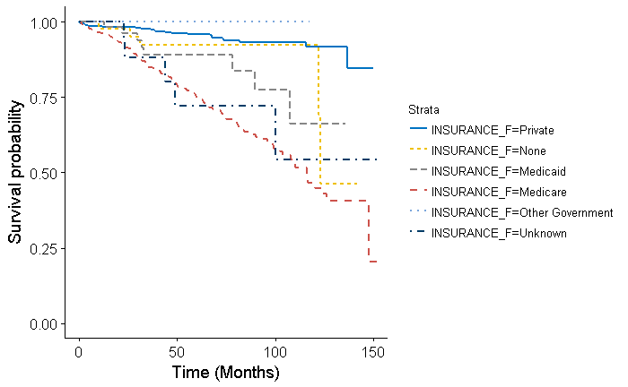

```r
uni_var(test_var = "INSURANCE_F", data_imp = data)
```

## Income

```
_________________________________________________

## INCOME_F
_________________________________________________
Call: survfit(formula = Surv(DX_LASTCONTACT_DEATH_MONTHS, PUF_VITAL_STATUS ==
    0) ~ INCOME_F, data = data)

   2 observations deleted due to missingness
                             n events median 0.95LCL 0.95UCL
INCOME_F=Less than $38,000 240     43    148     148      NA
INCOME_F=$38,000 - $47,999 256     50    137     123      NA
INCOME_F=$48,000 - $62,999 251     32     NA      NA      NA
INCOME_F=$63,000 +         313     38     NA      NA      NA

Call: survfit(formula = Surv(DX_LASTCONTACT_DEATH_MONTHS, PUF_VITAL_STATUS ==
    0) ~ INCOME_F, data = data)

2 observations deleted due to missingness
                INCOME_F=Less than $38,000
 time n.risk n.event survival std.err lower 95% CI upper 95% CI
   12    218       7    0.970  0.0111        0.949        0.992
   24    193       7    0.938  0.0161        0.907        0.970
   36    159      11    0.880  0.0227        0.837        0.926
   48    128       4    0.856  0.0250        0.809        0.907
   60    104       2    0.841  0.0267        0.791        0.895
  120     14      10    0.694  0.0529        0.597        0.805

                INCOME_F=$38,000 - $47,999
 time n.risk n.event survival std.err lower 95% CI upper 95% CI
   12    240      10    0.961  0.0122        0.937        0.985
   24    205       7    0.930  0.0164        0.899        0.963
   36    169       7    0.896  0.0203        0.857        0.936
   48    144       4    0.873  0.0228        0.829        0.919
   60    122       6    0.834  0.0267        0.784        0.888
  120     21      12    0.662  0.0539        0.564        0.776

                INCOME_F=$48,000 - $62,999
 time n.risk n.event survival std.err lower 95% CI upper 95% CI
   12    235       5    0.980 0.00906        0.962        0.997
   24    209       5    0.957 0.01332        0.931        0.983
```

[output cut: 29 more lines]

```
INCOME_F$48,000 - $62,999 -0.48382   0.61643  0.23409 -2.067   0.0388 *
INCOME_F$63,000 +         -0.48433   0.61611  0.22286 -2.173   0.0298 *
---
Signif. codes:  0 *** 0.001 ** 0.01 * 0.05 . 0.1   1

                          exp(coef) exp(-coef) lower .95 upper .95
INCOME_F$38,000 - $47,999    1.0195     0.9809    0.6778    1.5334
INCOME_F$48,000 - $62,999    0.6164     1.6223    0.3896    0.9753
INCOME_F$63,000 +            0.6161     1.6231    0.3981    0.9536

Concordance= 0.572  (se = 0.024 )
Rsquare= 0.009   (max possible= 0.854 )
Likelihood ratio test= 9.88  on 3 df,   p=0.01961
Wald test            = 9.75  on 3 df,   p=0.02078
Score (logrank) test = 9.95  on 3 df,   p=0.01897
```

```
Removed 1 rows containing missing values (geom_errorbar).
```

```
## Unadjusted Kaplan Meier Overall Survival Curve for:  INCOME_F
```

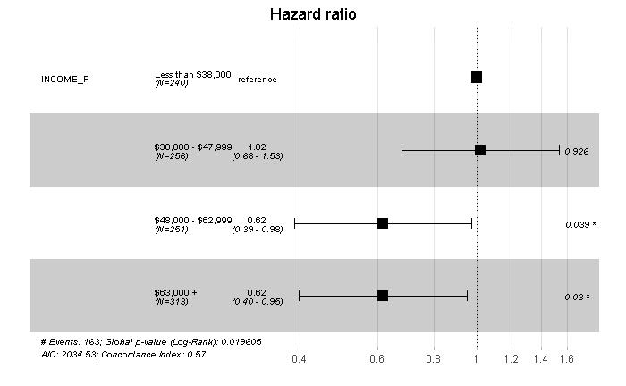

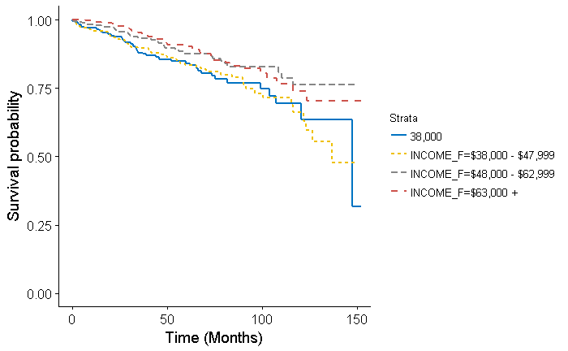

```r
uni_var(test_var = "INCOME_F", data_imp = data)
```

## Education

```
_________________________________________________

## EDUCATION_F
_________________________________________________
Call: survfit(formula = Surv(DX_LASTCONTACT_DEATH_MONTHS, PUF_VITAL_STATUS ==
    0) ~ EDUCATION_F, data = data)

   2 observations deleted due to missingness
                           n events median 0.95LCL 0.95UCL
EDUCATION_F=21% or more  225     39    148     148      NA
EDUCATION_F=13 - 20.9%   286     44     NA     137      NA
EDUCATION_F=7 - 12.9%    342     55     NA      NA      NA
EDUCATION_F=Less than 7% 207     25     NA      NA      NA

Call: survfit(formula = Surv(DX_LASTCONTACT_DEATH_MONTHS, PUF_VITAL_STATUS ==
    0) ~ EDUCATION_F, data = data)

2 observations deleted due to missingness
                EDUCATION_F=21% or more
 time n.risk n.event survival std.err lower 95% CI upper 95% CI
   12    202      11    0.950  0.0147        0.922        0.979
   24    174       7    0.915  0.0193        0.878        0.953
   36    140       5    0.886  0.0225        0.843        0.931
   48    113       2    0.872  0.0242        0.826        0.921
   60     95       2    0.857  0.0262        0.807        0.910
  120     13      10    0.700  0.0572        0.596        0.821

                EDUCATION_F=13 - 20.9%
 time n.risk n.event survival std.err lower 95% CI upper 95% CI
   12    271       5    0.982 0.00781        0.967        0.998
   24    242       2    0.975 0.00941        0.957        0.993
   36    210       9    0.936 0.01551        0.906        0.967
   48    177       7    0.903 0.01935        0.866        0.942
   60    149       6    0.870 0.02297        0.826        0.916
  120     30      12    0.721 0.04685        0.635        0.819

                EDUCATION_F=7 - 12.9%
 time n.risk n.event survival std.err lower 95% CI upper 95% CI
   12    323       5    0.985 0.00665        0.972        0.998
   24    278      14    0.940 0.01344        0.914        0.966
```

[output cut: 29 more lines]

```
EDUCATION_F7 - 12.9%    -0.1989    0.8197   0.2102 -0.946   0.3441
EDUCATION_FLess than 7% -0.4791    0.6193   0.2568 -1.865   0.0621 .
---
Signif. codes:  0 *** 0.001 ** 0.01 * 0.05 . 0.1   1

                        exp(coef) exp(-coef) lower .95 upper .95
EDUCATION_F13 - 20.9%      0.7327      1.365    0.4754     1.129
EDUCATION_F7 - 12.9%       0.8197      1.220    0.5429     1.237
EDUCATION_FLess than 7%    0.6193      1.615    0.3744     1.025

Concordance= 0.569  (se = 0.024 )
Rsquare= 0.004   (max possible= 0.854 )
Likelihood ratio test= 3.92  on 3 df,   p=0.2701
Wald test            = 3.93  on 3 df,   p=0.2693
Score (logrank) test = 3.97  on 3 df,   p=0.2648
```

```
Removed 1 rows containing missing values (geom_errorbar).
```

```
## Unadjusted Kaplan Meier Overall Survival Curve for:  EDUCATION_F
```

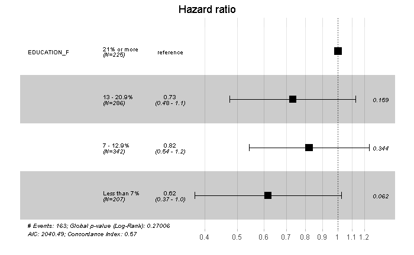

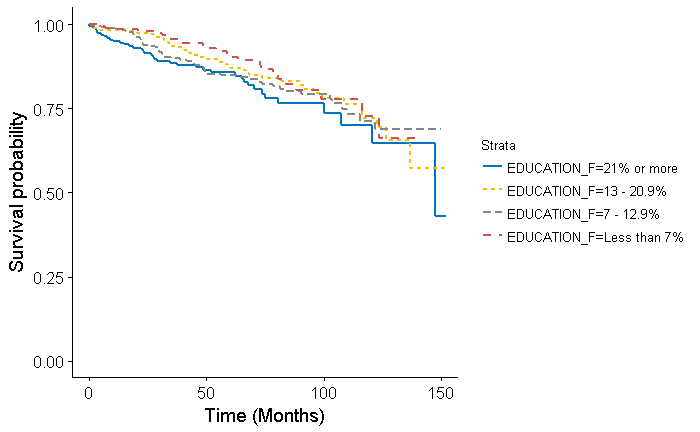

```r
uni_var(test_var = "EDUCATION_F", data_imp = data)
```

## Urban/Rural

```
_________________________________________________

## U_R_F
_________________________________________________
Call: survfit(formula = Surv(DX_LASTCONTACT_DEATH_MONTHS, PUF_VITAL_STATUS ==
    0) ~ U_R_F, data = data)

   23 observations deleted due to missingness
              n events median 0.95LCL 0.95UCL
U_R_F=Metro 872    131     NA     148      NA
U_R_F=Urban 154     26     NA     126      NA
U_R_F=Rural  13      2     NA     120      NA

Call: survfit(formula = Surv(DX_LASTCONTACT_DEATH_MONTHS, PUF_VITAL_STATUS ==
    0) ~ U_R_F, data = data)

23 observations deleted due to missingness
                U_R_F=Metro
 time n.risk n.event survival std.err lower 95% CI upper 95% CI
   12    818      18    0.979 0.00489        0.970        0.989
   24    711      24    0.948 0.00778        0.933        0.964
   36    601      22    0.917 0.01001        0.897        0.937
   48    499      14    0.894 0.01151        0.871        0.917
   60    415      12    0.871 0.01298        0.846        0.897
  120     72      36    0.719 0.02854        0.666        0.778

                U_R_F=Urban
 time n.risk n.event survival std.err lower 95% CI upper 95% CI
   12    144       4    0.973  0.0132        0.948        0.999
   24    134       0    0.973  0.0132        0.948        0.999
   36    104       7    0.917  0.0241        0.871        0.966
   48     85       3    0.889  0.0285        0.835        0.946
   60     67       5    0.831  0.0365        0.762        0.906
  120     11       6    0.693  0.0628        0.580        0.828

                U_R_F=Rural
 time n.risk n.event survival std.err lower 95% CI upper 95% CI
   12     12       1    0.923  0.0739        0.789            1
   24     12       0    0.923  0.0739        0.789            1
   36     11       0    0.923  0.0739        0.789            1
```

[output cut: 15 more lines]

```
   (23 observations deleted due to missingness)

              coef exp(coef) se(coef)      z Pr(>|z|)
U_R_FUrban  0.1385    1.1486   0.2149  0.645    0.519
U_R_FRural -0.2226    0.8004   0.7129 -0.312    0.755

           exp(coef) exp(-coef) lower .95 upper .95
U_R_FUrban    1.1486     0.8706    0.7538     1.750
U_R_FRural    0.8004     1.2494    0.1979     3.237

Concordance= 0.507  (se = 0.016 )
Rsquare= 0.001   (max possible= 0.852 )
Likelihood ratio test= 0.53  on 2 df,   p=0.767
Wald test            = 0.53  on 2 df,   p=0.7654
Score (logrank) test = 0.54  on 2 df,   p=0.7649
```

```
Removed 1 rows containing missing values (geom_errorbar).
```

```
## Unadjusted Kaplan Meier Overall Survival Curve for:  U_R_F
```

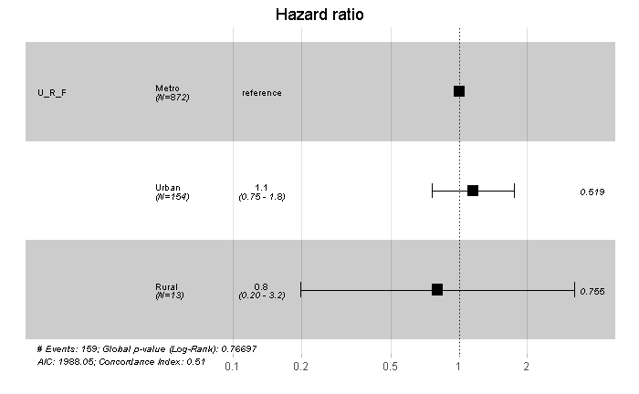

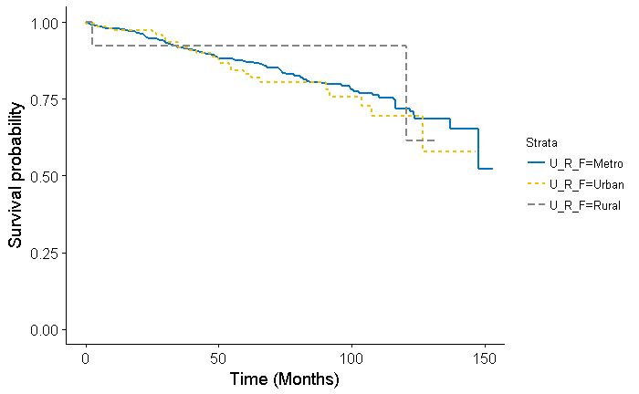

```r
uni_var(test_var = "U_R_F", data_imp = data)
```

## Comorbidities

```
_________________________________________________

## CDCC_TOTAL
_________________________________________________
Call: survfit(formula = Surv(DX_LASTCONTACT_DEATH_MONTHS, PUF_VITAL_STATUS ==
    0) ~ CDCC_TOTAL, data = data)

               n events median 0.95LCL 0.95UCL
CDCC_TOTAL=0 861    114     NA   147.6      NA
CDCC_TOTAL=1 166     41     NA    99.3      NA
CDCC_TOTAL=2  24      5     NA    99.0      NA
CDCC_TOTAL=3  11      3     NA    81.8      NA

Call: survfit(formula = Surv(DX_LASTCONTACT_DEATH_MONTHS, PUF_VITAL_STATUS ==
    0) ~ CDCC_TOTAL, data = data)

                CDCC_TOTAL=0
 time n.risk n.event survival std.err lower 95% CI upper 95% CI
   12    806      17    0.980 0.00484        0.970        0.989
   24    714      17    0.958 0.00709        0.944        0.972
   36    599      19    0.930 0.00927        0.912        0.949
   48    505      10    0.914 0.01050        0.893        0.935
   60    421      12    0.891 0.01216        0.867        0.915
  120     78      32    0.755 0.02735        0.703        0.811

                CDCC_TOTAL=1
 time n.risk n.event survival std.err lower 95% CI upper 95% CI
   12    155       5    0.969  0.0135        0.943        0.996
   24    132       7    0.923  0.0214        0.882        0.966
   36    112       9    0.857  0.0292        0.801        0.916
   48     85       6    0.806  0.0340        0.742        0.875
   60     65       4    0.763  0.0383        0.692        0.842
  120      6      10    0.522  0.0784        0.389        0.700

                CDCC_TOTAL=2
 time n.risk n.event survival std.err lower 95% CI upper 95% CI
   12     23       1    0.958  0.0408        0.882        1.000
   24     19       0    0.958  0.0408        0.882        1.000
   36     14       1    0.902  0.0668        0.780        1.000
   48     11       1    0.833  0.0908        0.672        1.000
```

[output cut: 26 more lines]

```
CDCC_TOTAL2 0.5014    1.6510   0.4573 1.096    0.273
CDCC_TOTAL3 0.6656    1.9456   0.5853 1.137    0.255
---
Signif. codes:  0 *** 0.001 ** 0.01 * 0.05 . 0.1   1

            exp(coef) exp(-coef) lower .95 upper .95
CDCC_TOTAL1     2.168     0.4613    1.5150     3.102
CDCC_TOTAL2     1.651     0.6057    0.6738     4.046
CDCC_TOTAL3     1.946     0.5140    0.6178     6.127

Concordance= 0.567  (se = 0.017 )
Rsquare= 0.016   (max possible= 0.853 )
Likelihood ratio test= 16.86  on 3 df,   p=0.0007543
Wald test            = 18.94  on 3 df,   p=0.0002813
Score (logrank) test = 19.85  on 3 df,   p=0.000182
```

```
Removed 1 rows containing missing values (geom_errorbar).
```

```
## Unadjusted Kaplan Meier Overall Survival Curve for:  CDCC_TOTAL
```

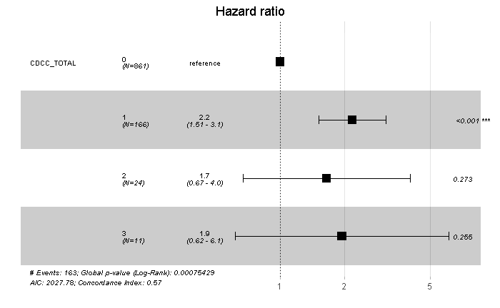

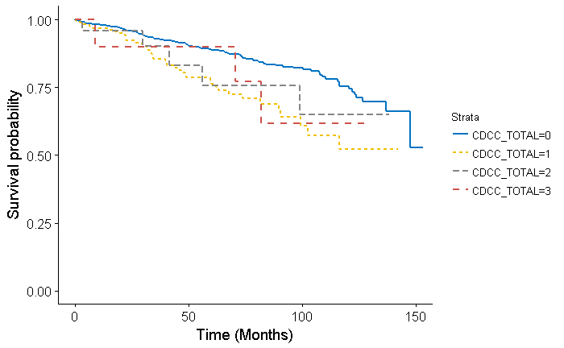

```r
uni_var(test_var = "CDCC_TOTAL", data_imp = data)
```